# DS07 - Linear Regression

Victor Ivamoto

05/11/2019

# 1 Section 1: Introduction to Regression

## 1.1 Introduction to Regression Overview

In the **Introduction to Regression** section, you will learn the basics of linear regression.

After completing this section, you will be able to:

- Understand how Galton developed **linear regression**.
- Calculate and interpret the **sample correlation**.
- **Stratify** a dataset when appropriate.
- Understand what a **bivariate normal distribution** is.
- Explain what the term **variance explained** means.
- Interpret the two **regression lines**.

This section has three parts: **Baseball as a Motivating Example**, **Correlation**, and **Stratification and Variance Explained**. There are comprehension checks at the end of each part.

We encourage you to use R to interactively test out your answers and further your own learning. If you get stuck, we encourage you to search the discussion boards for the answer to your issue or ask us for help!

## 1.2 1.1: Baseball as a Motivating Example

### 1.2.1 Motivating Example: Moneyball

**Textbook link**  
The corresponding section of the textbook is the [case study on Moneyball.](https://rafalab.github.io/dsbook/linear-models.html#case-study-moneyball)

**Key points**

- Bill James was the originator of the **sabermetrics**, the approach of using data to predict what outcomes best predicted if a team would win

### 1.2.2 Baseball Basics

**Textbook link**  
The corresponding textbook section on [baseball basics can be found here.](https://rafalab.github.io/dsbook/linear-models.html#baseball-basics)

**Key points**

- The goal of a baseball game is to score more runs (points) than the other team.
- Each team has 9 batters who have an opportunity to hit a ball with a bat in a predetermined order.
- Each time a batter has an opportunity to bat, we call it a plate appearance (PA).
- The PA ends with a binary outcome: the batter either makes an out (failure) and returns to the bench or the batter doesn’t (success) and can run around the bases, and potentially score a run (reach all 4 bases).
- We are simplifying a bit, but there are five ways a batter can succeed (not make an out):
  1. Bases on balls (BB): the pitcher fails to throw the ball through a predefined area considered to be hittable (the strike zone), so the batter is permitted to go to first base.
  2. Single: the batter hits the ball and gets to first base.
  3. Double (2B): the batter hits the ball and gets to second base.
  4. Triple (3B): the batter hits the ball and gets to third base.
  5. Home Run (HR): the batter hits the ball and goes all the way home and scores a run.
- Historically, the batting average has been considered the most important offensive statistic. To define this average, we define a hit (H) and an at bat (AB). Singles, doubles, triples and home runs are hits. The fifth way to be successful, a walk (BB), is not a hit. An AB is the number of times you either get a hit or make an out; BBs are excluded. The batting average is simply H/AB and is considered the main measure of a success rate.

### 1.2.3 Bases on Balls or Stolen Bases?

**Textbook link**  
The corresponding section of the textbook is [base on balls or stolen bases.](https://rafalab.github.io/dsbook/linear-models.html#base-on-balls-or-stolen-bases)

**Key points**

- The visualization of choice when exploring the relationship between two variables like home runs and runs is a scatterplot.

```r
library(Lahman)
library(tidyverse)
```

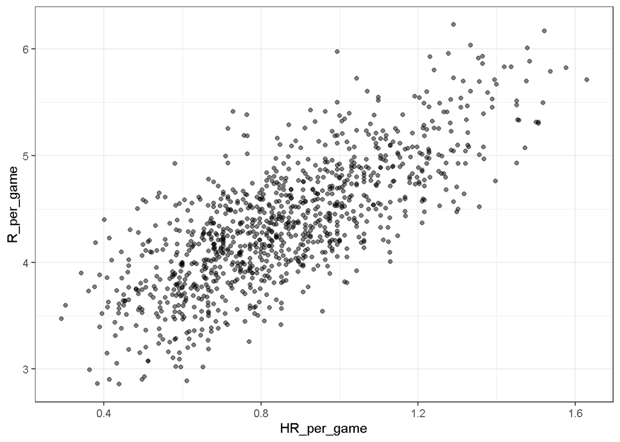

```r
library(dslabs)
ds_theme_set()

Teams %>% filter(yearID %in% 1961:2001) %>%
    mutate(HR_per_game = HR / G, R_per_game = R / G) %>%
    ggplot(aes(HR_per_game, R_per_game)) +
    geom_point(alpha = 0.5)
```

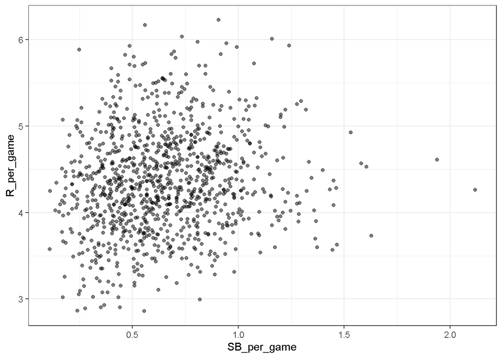

```r
Teams %>% filter(yearID %in% 1961:2001) %>%
    mutate(SB_per_game = SB / G, R_per_game = R / G) %>%
    ggplot(aes(SB_per_game, R_per_game)) +
    geom_point(alpha = 0.5)
```

Scatterplot of the relationship between bases on balls and runs

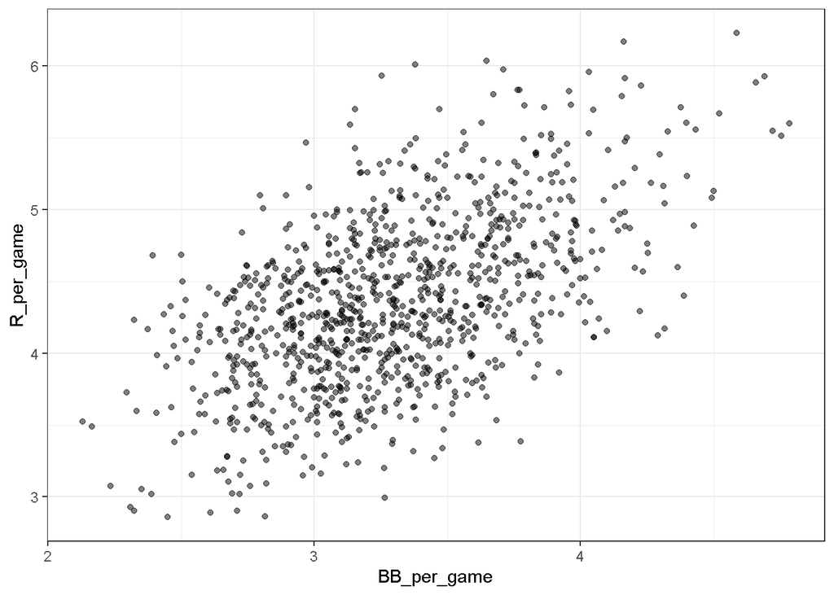

```r
Teams %>% filter(yearID %in% 1961:2001) %>%
    mutate(BB_per_game = BB / G, R_per_game = R / G) %>%
    ggplot(aes(BB_per_game, R_per_game)) +
    geom_point(alpha = 0.5)
```

### 1.2.4 Assessment: Baseball as a Motivating Example

#### 1.2.4.1 Question 1

What is the application of statistics and data science to baseball called?

- Moneyball
- **Sabermetrics**
- The “Oakland A’s Approach”
- There is no specific name for this; it’s just data science.

**Answer**  
The term “sabermetrics” was coined by Bill James, and is derived from the acronym SABR: the society for American baseball research.

#### 1.2.4.2 Question 2

Which of the following outcomes is not included in the batting average?

- A home run
- **A base on balls**
- An out
- A single

**Answer**  
A base on balls is not considered a hit and is excluded from the at-bat total.

#### 1.2.4.3 Question 3

Why do we consider team statistics as well as individual player statistics?

- **The success of any individual player also depends on the strength of their team.**
- Team statistics can be easier to calculate.
- The ultimate goal of sabermetrics is to rank teams, not players.

**Explanation**  
Team statistics are important because the success of individual players depends also on the strength of their team.

#### 1.2.4.4 Question 4

You want to know whether teams with more at-bats per game have more runs per game.

What R code below correctly makes a scatter plot for this relationship?

```
Teams %>% filter(yearID %in% 1961:2001 ) %>%
    ggplot(aes(AB, R)) +
    geom_point(alpha = 0.5)
```

- **`Teams %>% filter(yearID %in% 1961:2001 ) %>%`**  
  **`mutate(AB_per_game = AB/G, R_per_game = R/G) %>%`**  
  **`ggplot(aes(AB_per_game, R_per_game)) +`**  
  **`geom_point(alpha = 0.5)`**

```
Teams %>% filter(yearID %in% 1961:2001 ) %>%
    mutate(AB_per_game = AB/G, R_per_game = R/G) %>%
    ggplot(aes(AB_per_game, R_per_game)) +
    geom_line()
```

```
Teams %>% filter(yearID %in% 1961:2001 ) %>%
    mutate(AB_per_game = AB/G, R_per_game = R/G) %>%
    ggplot(aes(R_per_game, AB_per_game)) +
    geom_point()
```

**Answer**  
This makes a scatter plot of runs per game (y-axis) vs. at-bats per game (x-axis).

#### 1.2.4.5 Question 5

What does the variable “SOA” stand for in the `Teams` table? Hint: make sure to use the help file (`?Teams`).

- sacrifice out
- slides or attempts
- **strikeouts by pitchers**
- accumulated singles

#### 1.2.4.6 Question 6

Load the **Lahman** library. Filter the `Teams` data frame to include years from 1961 to 2001. Make a scatterplot of runs per game versus at bats (`AB`) per game.

Which of the following is true?

- There is no clear relationship between runs and at bats per game.
- **As the number of at bats per game increases, the number of runs per game tends to increase.**
- As the number of at bats per game increases, the number of runs per game tends to decrease.

**Explanation**  
When you examine the scatterplot, you can see a clear trend towards increasing runs per game with increasing number of at-bats per game. The following code can be used to make the scatterplot:

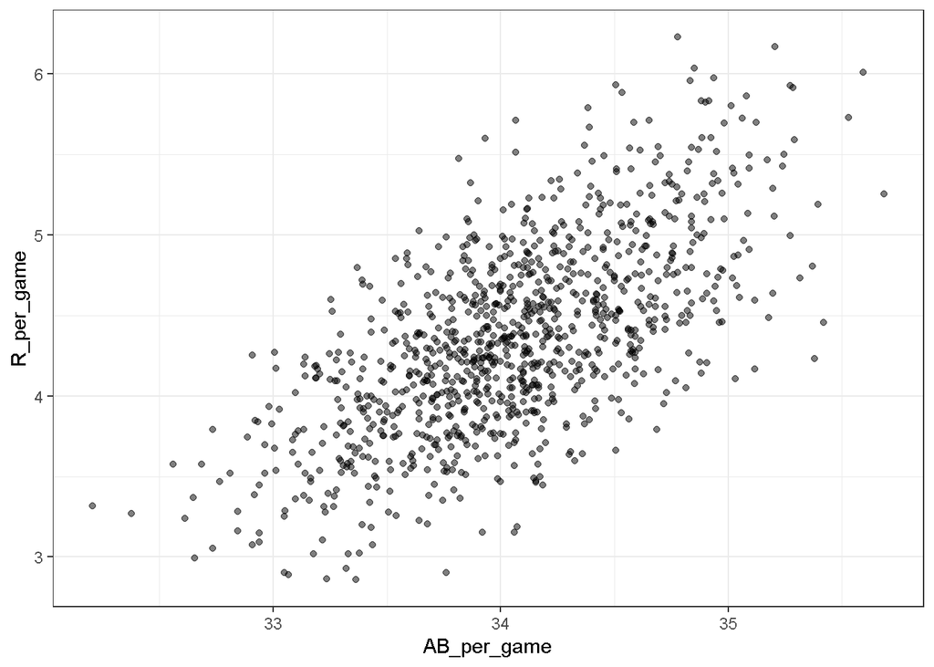

```r
library(Lahman)
library(tidyverse)
library(dslabs)
Teams %>% filter(yearID %in% 1961:2001) %>%
  mutate(AB_per_game = AB / G, R_per_game = R / G) %>%
  ggplot(aes(AB_per_game, R_per_game)) +
  geom_point(alpha = 0.5)
```

#### 1.2.4.7 Question 7

Use the filtered `Teams` data frame from Question 6. Make a scatterplot of win rate (number of wins per game) versus number of fielding errors (`E`) per game.

Which of the following is true?

- There is no clear relationship between win rate and errors per game.
- As the number of errors per game increases, the win rate tends to increase.
- **As the number of errors per game increases, the win rate tends to decrease.**

**Explanation**  
When you examine the scatterplot, you can see a clear trend towards decreased win rate with increasing number of errors per game. The following code can be used to make the scatterplot:

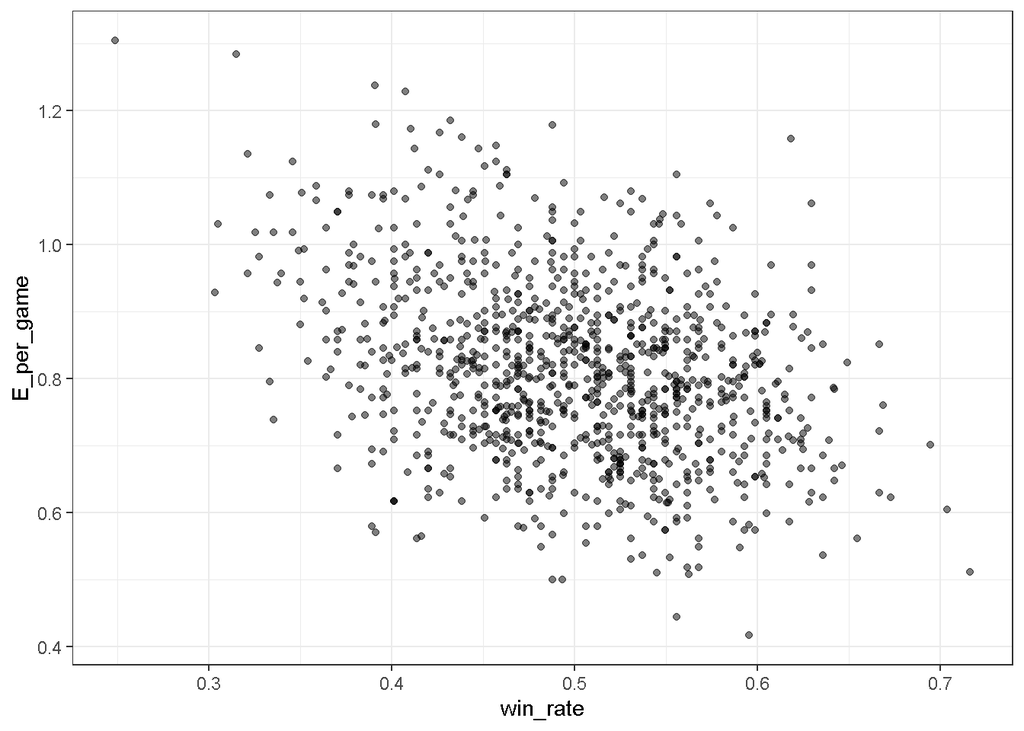

```r
Teams %>% filter(yearID %in% 1961:2001) %>%
  mutate(win_rate = W / G, E_per_game = E / G) %>%
  ggplot(aes(win_rate, E_per_game)) +
  geom_point(alpha = 0.5)
```

#### 1.2.4.8 Question 8

Use the filtered `Teams` data frame from Question 6. Make a scatterplot of triples (`X3B`) per game versus doubles (`X2B`) per game.

Which of the following is true?

- **There is no clear relationship between doubles per game and triples per game.**
- As the number of doubles per game increases, the number of triples per game tends to increase.
- As the number of doubles per game increases, the number of triples per game tends to decrease.

**Explanation**  
When you examine the scatterplot, you can see no clear relationship between doubles and triples per game. The following code can be used to make the scatterplot:

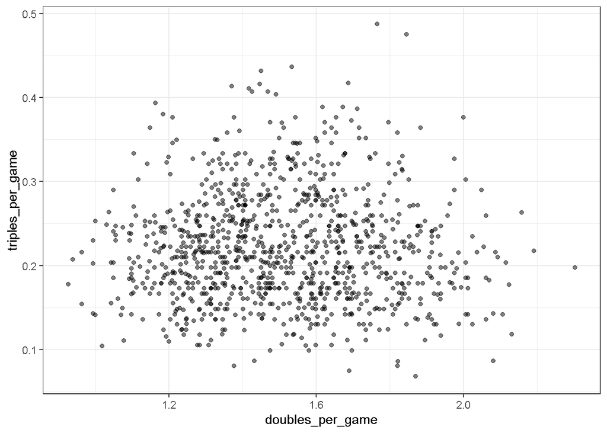

```r
Teams %>% filter(yearID %in% 1961:2001) %>%
  mutate(doubles_per_game = X2B / G, triples_per_game = X3B / G) %>%
  ggplot(aes(doubles_per_game, triples_per_game)) +
  geom_point(alpha = 0.5)
```

## 1.3 1.2: Correlation

### 1.3.1 Correlation

**Textbook link**  
The corresponding textbook section is the [Case Study: is height hereditary?](https://rafalab.github.io/dsbook/regression.html#case-study-is-height-hereditary)

**Key points**

- Galton tried to predict sons’ heights based on fathers’ heights.
- The mean and standard errors are insufficient for describing an important characteristic of the data: the trend that the taller the father, the taller the son.
- The correlation coefficient is an informative summary of how two variables move together that can be used to predict one variable using the other.

**Code**

```r
# create the dataset
library(tidyverse)
library(HistData)
data("GaltonFamilies")
set.seed(1983)
galton_heights <- GaltonFamilies %>%
  filter(gender == "male") %>%
  group_by(family) %>%
  sample_n(1) %>%
  ungroup() %>%
  select(father, childHeight) %>%
  rename(son = childHeight)

# means and standard deviations
galton_heights %>%
    summarize(mean(father), sd(father), mean(son), sd(son))
```

```
## # A tibble: 1 x 4
##   `mean(father)` `sd(father)` `mean(son)` `sd(son)`
##            <dbl>        <dbl>       <dbl>     <dbl>
## 1           69.1         2.55        69.2      2.71
```

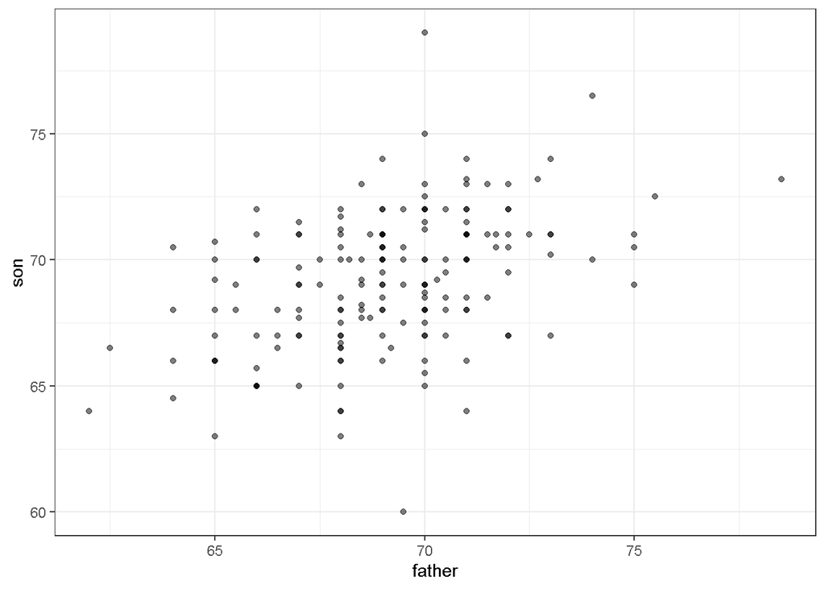

```r
# scatterplot of father and son heights
galton_heights %>%
    ggplot(aes(father, son)) +
    geom_point(alpha = 0.5)
```

### 1.3.2 Correlation Coefficient

**Textbook link**  
The [correlation coefficient section of the textbook can be found here.](https://rafalab.github.io/dsbook/regression.html#the-correlation-coefficient)

**Key points**

- The correlation coefficient is defined for a list of pairs $(x_1,y_1),...,(x_n,y_n)$ as the product of the standardized values: $\left ( \frac{x_i−\mu_x}{\sigma_x}\right )\left (\frac{y_i−\mu_y}{\sigma_y}\right )$.
- The correlation coefficient essentially conveys how two variables move together.
- The correlation coefficient is always between -1 and 1.

**Code**

```r
# objects 'x' and 'y' not found
#rho <- mean(scale(x)*scale(y))
galton_heights %>% summarize(r = cor(father, son)) %>% pull(r)
```

```
## [1] 0.4334102
```

### 1.3.3 Sample Correlation is a Random Variable

**Textbook link**  
The [sample correlation is a random variable section of the textbook can be found here.](https://rafalab.github.io/dsbook/regression.html#sample-correlation-is-a-random-variable)

**Key points**

- The correlation that we compute and use as a summary is a random variable.
- When interpreting correlations, it is important to remember that correlations derived from samples are estimates containing uncertainty.
- Because the sample correlation is an average of independent draws, the central limit theorem applies.

**Code**

```r
# compute sample correlation
R <- sample_n(galton_heights, 25, replace = TRUE) %>%
    summarize(r = cor(father, son))
R
```

```
## # A tibble: 1 x 1
##       r
##   <dbl>
## 1 0.463
```

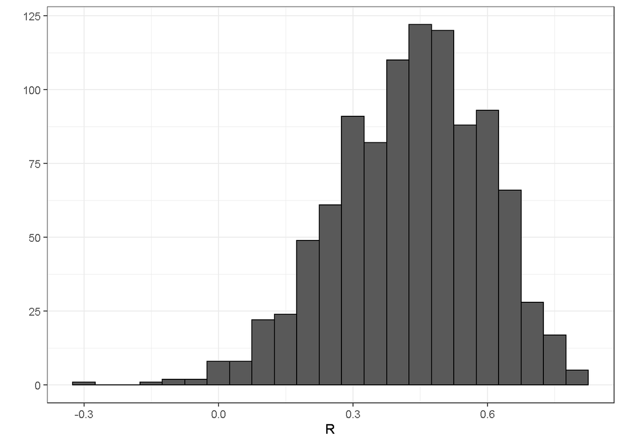

```r
# Monte Carlo simulation to show distribution of sample correlation
B <- 1000
N <- 25
R <- replicate(B, {
    sample_n(galton_heights, N, replace = TRUE) %>%
    summarize(r = cor(father, son)) %>%
    pull(r)
})
qplot(R, geom = "histogram", binwidth = 0.05, color = I("black"))
```

```r
# expected value and standard error
mean(R)
```

```
## [1] 0.4291816
```

```r
sd(R)
```

```
## [1] 0.1663783
```

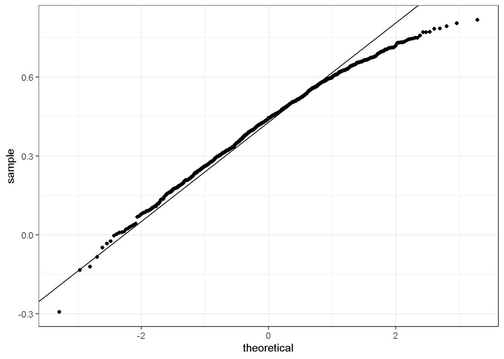

```r
# QQ-plot to evaluate whether N is large enough
data.frame(R) %>%
    ggplot(aes(sample = R)) +
    stat_qq() +
    geom_abline(intercept = mean(R), slope = sqrt((1-mean(R)^2)/(N-2)))
```

### 1.3.4 Assessment: Correlation

#### 1.3.4.1 Question 1

While studying heredity, Francis Galton developed what important statistical concept?

- Standard deviation
- Normal distribution
- **Correlation**
- Probability

**Explanation**  
Francis Galton developed the concept of correlation while study heredity.

#### 1.3.4.2 Question 2

The correlation coefficient is a summary of what?

- **The trend between two variables**
- The dispersion of a variable
- The central tendency of a variable
- The distribution of a variable

#### 1.3.4.3 Question 3

Below is a scatter plot showing the relationship between two variables, x and y.

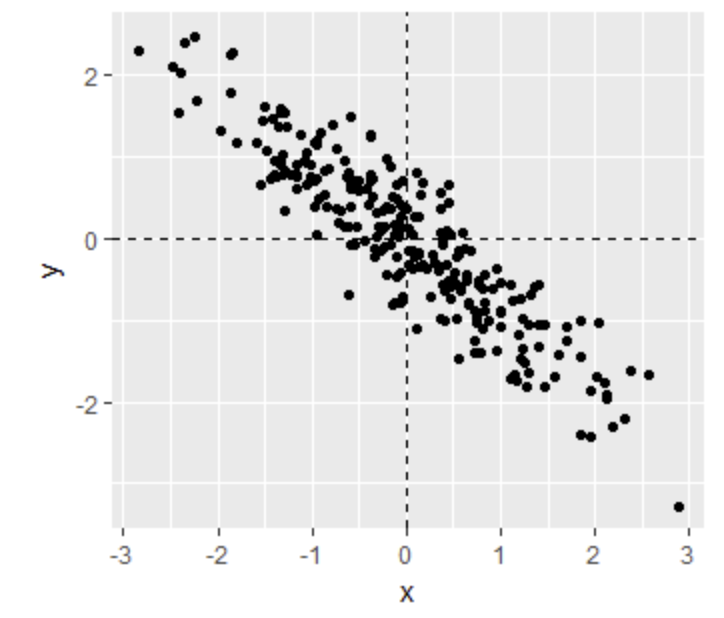

From this figure, the correlation between x and y appears to be about:

- **-0.9**
- -0.2
- 0.9
- 2

**Answer**  
The variables x and y have a strong negative relationship with each other; as x increases, y decreases.

#### 1.3.4.4 Question 4

Instead of running a Monte Carlo simulation with a sample size of 25 from the 179 father-son pairs described in the videos, we now run our simulation with a sample size of 50.

Would you expect the **mean** of our sample correlation to increase, decrease, or stay approximately the same?

- Increase
- Decrease
- **Stay approximately the same**

**Explanation**  
Because the expected value of the sample correlation is the population correlation, it should stay approximately the same even if the sample size is increased.

#### 1.3.4.5 Question 5

Instead of running a Monte Carlo simulation with a sample size of 25 from the 179 father-son pairs described in the videos, we now run our simulation with a sample size of 50.

Would you expect the **standard deviation** of our sample correlation to increase, decrease, or stay approximately the same?

- Increase
- **Decrease**
- Stay approximately the same

**Explanation**  
As the sample size N increases, the standard deviation of the sample correlation should decrease.

#### 1.3.4.6 Question 6

If X and Y are completely independent, what do you expect the value of the correlation coefficient to be?

- -1
- -0.5
- **0**
- 0.5
- 1
- Not enough information to answer the question

**Answer**  
If X and Y are independent, then their correlation coefficient is 0.

#### 1.3.4.7 Question 7

Load the **Lahman** library. Filter the `Teams` data frame to include years from 1961 to 2001.

What is the correlation coefficient between number of runs per game and number of at bats per game?

```r
library(Lahman)
Teams_small <- Teams %>% filter(yearID %in% 1961:2001)
cor(Teams_small$R/Teams_small$G, Teams_small$AB/Teams_small$G)
```

```
## [1] 0.6580976
```

#### 1.3.4.8 Question 8

Use the filtered `Teams` data frame from Question 7.

What is the correlation coefficient between win rate (number of wins per game) and number of errors per game?

```r
cor(Teams_small$W/Teams_small$G, Teams_small$E/Teams_small$G)
```

```
## [1] -0.3396947
```

#### 1.3.4.9 Question 9

Use the filtered `Teams` data frame from Question 7.

What is the correlation coefficient between doubles (`X2B`) per game and triples (`X3B`) per game?

```r
cor(Teams_small$X2B/Teams_small$G, Teams_small$X3B/Teams_small$G)
```

```
## [1] -0.01157404
```

## 1.4 1.3: Stratification and Variance Explained

### 1.4.1 Anscombe’s Quartet/Stratification

**Textbook link**  
There are three links to relevant sections of the textbook for this video:

- [correlation is not always a useful summary](https://rafalab.github.io/dsbook/regression.html#correlation-is-not-always-a-useful-summary)
- [conditional expectation](https://rafalab.github.io/dsbook/regression.html#conditional-expectation)
- [the regression line](https://rafalab.github.io/dsbook/regression.html#the-regression-line)

**Key points**

- Correlation is not always a good summary of the relationship between two variables.
- The general idea of conditional expectation is that we stratify a population into groups and compute summaries in each group.
- A practical way to improve the estimates of the conditional expectations is to define strata of with similar values of x.
- If there is perfect correlation, the regression line predicts an increase that is the same number of SDs for both variables. If there is 0 correlation, then we don’t use x at all for the prediction and simply predict the average $\mu_y$ . For values between 0 and 1, the prediction is somewhere in between. If the correlation is negative, we predict a reduction instead of an increase.

**Code**

```r
# number of fathers with height 72 or 72.5 inches
sum(galton_heights$father == 72)
```

```
## [1] 8
```

```r
sum(galton_heights$father == 72.5)
```

```
## [1] 1
```

```r
# predicted height of a son with a 72 inch tall father
conditional_avg <- galton_heights %>%
    filter(round(father) == 72) %>%
    summarize(avg = mean(son)) %>%
    pull(avg)
conditional_avg
```

```
## [1] 70.5
```

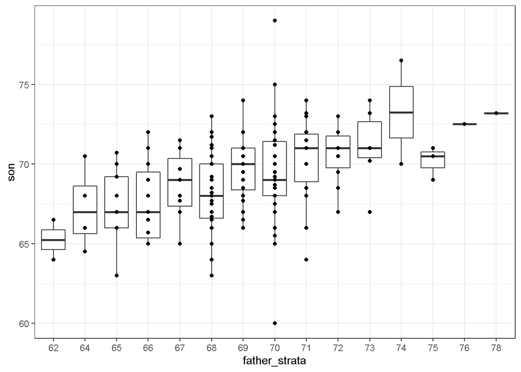

```r
# stratify fathers' heights to make a boxplot of son heights
galton_heights %>% mutate(father_strata = factor(round(father))) %>%
    ggplot(aes(father_strata, son)) +
    geom_boxplot() +
    geom_point()
```

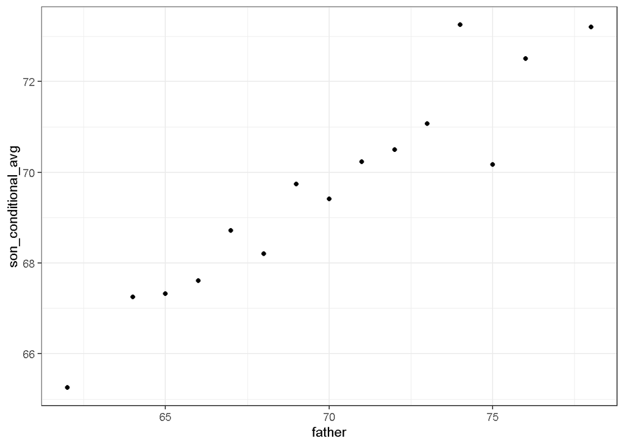

```r
# center of each boxplot
galton_heights %>%
    mutate(father = round(father)) %>%
    group_by(father) %>%
    summarize(son_conditional_avg = mean(son)) %>%
    ggplot(aes(father, son_conditional_avg)) +
    geom_point()
```

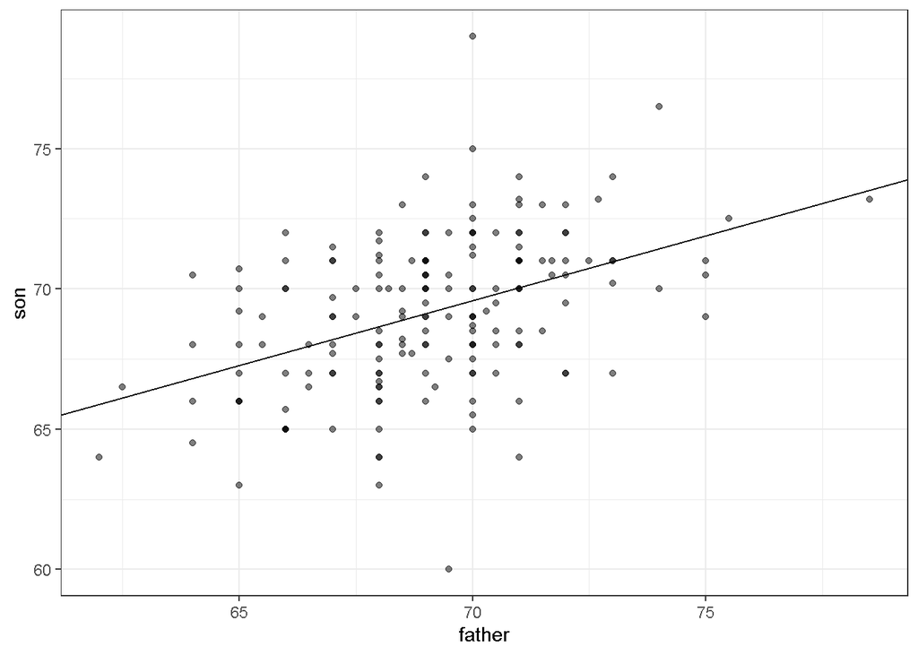

```r
# calculate values to plot regression line on original data
mu_x <- mean(galton_heights$father)
mu_y <- mean(galton_heights$son)
s_x <- sd(galton_heights$father)
s_y <- sd(galton_heights$son)
r <- cor(galton_heights$father, galton_heights$son)
m <- r * s_y/s_x
b <- mu_y - m*mu_x

# add regression line to plot
galton_heights %>%
    ggplot(aes(father, son)) +
    geom_point(alpha = 0.5) +
    geom_abline(intercept = b, slope = m)
```

### 1.4.2 Bivariate Normal Distribution

**Textbook link**  
The link to the corresponding textbook section is [bivariate normal distribution (advanced).](https://rafalab.github.io/dsbook/regression.html#bivariate-normal-distribution-advanced)

**Key points**

- When a pair of random variables are approximated by the bivariate normal distribution, scatterplots look like ovals. They can be thin (high correlation) or circle-shaped (no correlation).
- When two variables follow a bivariate normal distribution, computing the regression line is equivalent to computing conditional expectations.
- We can obtain a much more stable estimate of the conditional expectation by finding the regression line and using it to make predictions.

**Code**

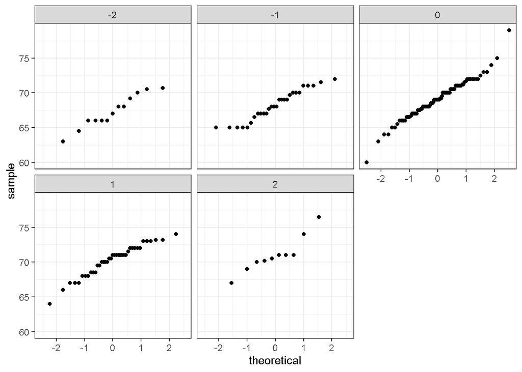

```r
galton_heights %>%
  mutate(z_father = round((father - mean(father)) / sd(father))) %>%
  filter(z_father %in% -2:2) %>%
  ggplot() +
  stat_qq(aes(sample = son)) +
  facet_wrap( ~ z_father)
```

### 1.4.3 Variance Explained

**Correction**  
The equation shown at 0:10 is for the *standard deviation* of the conditional distribution, not the *variance*. The variance is the standard deviation squared. See the notes below the video for more clarification.

**Textbook link**  
The section on [variance explained from the textbook can be found here.](https://rafalab.github.io/dsbook/regression.html#variance-explained)

**Key points**

- Conditioning on a random variable X can help to reduce variance of response variable Y.
- The standard deviation of the conditional distribution is $SD(Y∣X=x)=\sigma_y\sqrt{1−\rho^2}$ , which is smaller than the standard deviation without conditioning $\sigma_y$.
- Because variance is the standard deviation squared, the variance of the conditional distribution is $\sigma^2_y(1−\rho^2)$.
- In the statement “X explains such and such percent of the variability,” the percent value refers to the variance. The variance decreases by $\rho^2$ percent.
- The “variance explained” statement only makes sense when the data is approximated by a bivariate normal distribution.

### 1.4.4 There are Two Regression Lines

**Textbook link**  
The link to the corresponding section of the textbook is [warning: there are two regression lines.](https://rafalab.github.io/dsbook/regression.html#warning-there-are-two-regression-lines)

**Key point**

- There are two different regression lines depending on whether we are taking the expectation of Y given X or taking the expectation of X given Y.

**Code**

```r
# compute a regression line to predict the son's height from the father's height
mu_x <- mean(galton_heights$father)
mu_y <- mean(galton_heights$son)
s_x <- sd(galton_heights$father)
s_y <- sd(galton_heights$son)
r <- cor(galton_heights$father, galton_heights$son)
m_1 <-  r * s_y / s_x
b_1 <- mu_y - m_1*mu_x

# compute a regression line to predict the father's height from the son's height
m_2 <-  r * s_x / s_y
b_2 <- mu_x - m_2*mu_y
```

### 1.4.5 Assessment: Stratification and Variance Explained, Part 1

#### 1.4.5.1 Question 1

Look at the figure below.

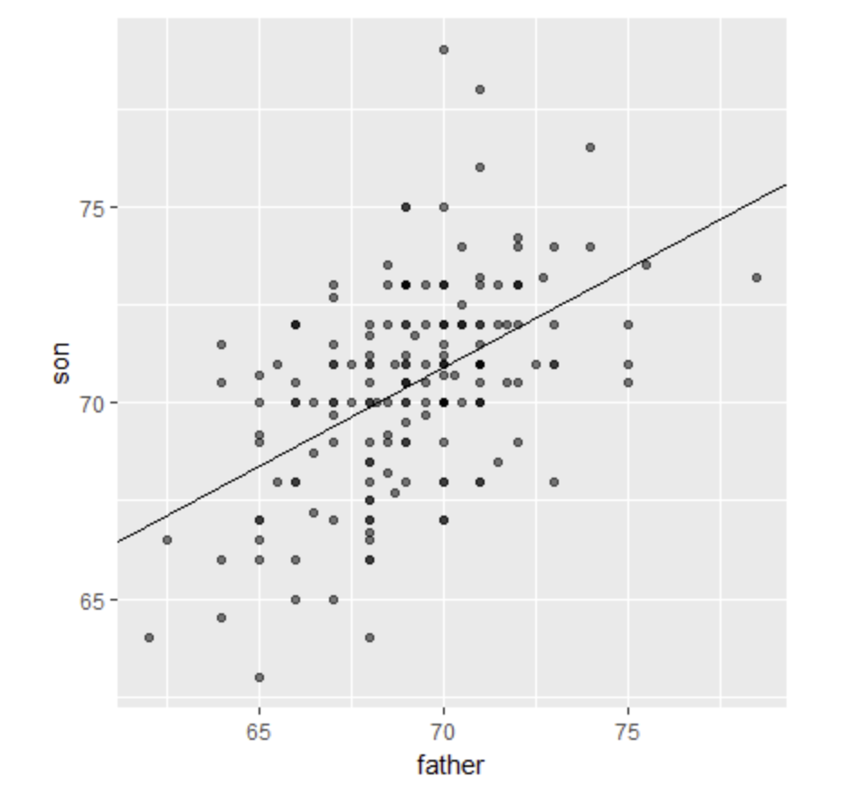

The slope of the regression line in this figure is equal to what, in words?

- **`Slope = (correlation coefficient of son and father heights) * (standard deviation of sons’ heights / standard deviation of fathers’ heights)`**

```
Slope = (correlation coefficient of son and father heights) * (standard deviation of fathers’ heights / standard deviation of sons’ heights)
```

```
Slope = (correlation coefficient of son and father heights) / (standard deviation of sons’ heights * standard deviation of fathers’ heights)
```

```
Slope = (mean height of fathers) - (correlation coefficient of son and father heights * mean height of sons).
```

#### 1.4.5.2 Question 2

Why does the regression line simplify to a line with intercept zero and slope $\rho$ when we standardize our x and y variables? Try the simplification on your own first!

- When we standardize variables, both x and y will have a mean of one and a standard deviation of zero. When you substitute this into the formula for the regression line, the terms cancel out until we have the following equation: $y_i=\rho x_i$.
- **When we standardize variables, both x and y will have a mean of zero and a standard deviation of one. When you substitute this into the formula for the regression line, the terms cancel out until we have the following equation:** $\mathbf{y_i=\rho x_i}$.
- When we standardize variables, both x and y will have a mean of zero and a standard deviation of one. When you substitute this into the formula for the regression line, the terms cancel out until we have the following equation: $y_i=\rho+x_i$.

**Explanation**  
When we standardize variables, they have a mean of 0 and a standard deviation of 1, giving the equation $y_i=\rho x_i$. The equation $y_i=\rho+x_i$ is for a line with an intercept equal to the correlation coefficient, but the regression line simplifies to have an intercept of 0 when we standardize variables.

#### 1.4.5.3 Question 3

What is a limitation of calculating conditional means? Select ALL that apply.

- **Each stratum we condition on (e.g., a specific father’s height) may not have many data points.**
- **Because there are limited data points for each stratum, our average values have large standard errors.**
- **Conditional means are less stable than a regression line.**
- Conditional means are a useful theoretical tool but cannot be calculated. correta

#### 1.4.5.4 Question 4

A regression line is the best prediction of Y given we know the value of X when:

- **X and Y follow a bivariate normal distribution.**
- Both X and Y are normally distributed.
- Both X and Y have been standardized.
- There are at least 25 X-Y pairs.

#### 1.4.5.5 Question 5

Which one of the following scatterplots depicts an x and y distribution that is NOT well-approximated by the bivariate normal distribution?

- **Correct**

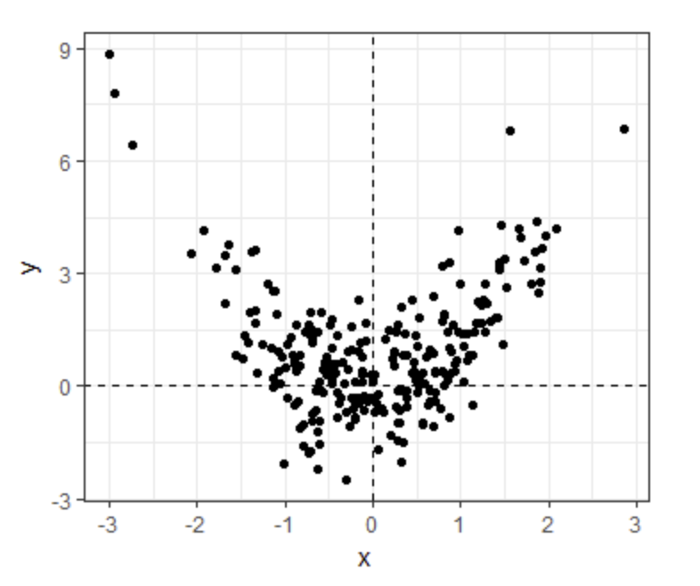

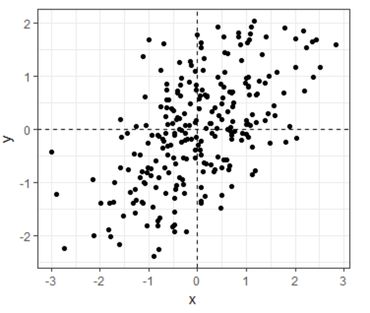

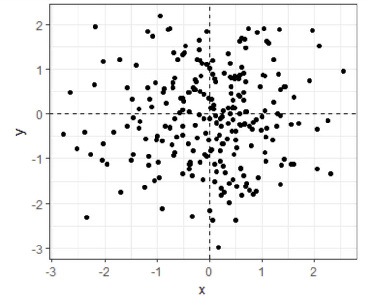

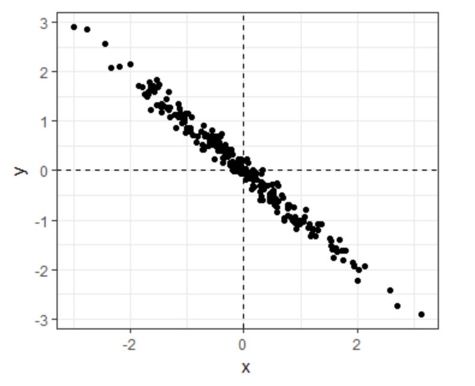

**Explanation**  
The v-shaped distribution of points from the first plot means that the x and y variables do not follow a bivariate normal distribution. When a pair of random variables is approximated by a bivariate normal, the scatter plot looks like an oval (as in the 2nd, 3rd, and 4th plots) - it is okay if the oval is very round (as in the 3rd plot) or long and thin (as in the 4th plot).

#### 1.4.5.6 Question 6

We previously calculated that the correlation coefficient $\rho$ between fathers’ and sons’ heights is 0.5.

Given this, what percent of the variation in sons’ heights is explained by fathers’ heights?

- 0%
- **25%**
- 50%
- 75%

**Answer**  
When two variables follow a bivariate normal distribution, the variation explained can be calculated as $\rho^2×100$ .

#### 1.4.5.7 Question 7

Suppose the correlation between father and son’s height is 0.5, the standard deviation of fathers’ heights is 2 inches, and the standard deviation of sons’ heights is 3 inches.

Given a one inch increase in a father’s height, what is the predicted change in the son’s height?

- 0.333
- 0.5
- 0.667
- **0.75**
- 1
- 1.5

**Answer**  
The slope of the regression line is calculated by multiplying the correlation coefficient by the ratio of the standard deviation of son heights and standard deviation of father heights: $\sigma_{son}/\sigma_{father}$.

### 1.4.6 Assessment: Stratification and Variance Explained, Part 2

In the second part of this assessment, you’ll analyze a set of mother and daughter heights, also from **GaltonFamilies**.

Define **`female_heights`**, a set of mother and daughter heights sampled from **GaltonFamilies**, as follows:

```r
set.seed(1989, sample.kind="Rounding") #if you are using R 3.6 or later
```

```r
library(HistData)
data("GaltonFamilies")

female_heights <- GaltonFamilies%>%
    filter(gender == "female") %>%
    group_by(family) %>%
    sample_n(1) %>%
    ungroup() %>%
    select(mother, childHeight) %>%
    rename(daughter = childHeight)
```

#### 1.4.6.1 Question 8

5.0/5.0 points (graded) Calculate the mean and standard deviation of mothers’ heights, the mean and standard deviation of daughters’ heights, and the correlaton coefficient between mother and daughter heights.

Mean of mothers’ heights

```r
mean(female_heights$mother)
```

```
## [1] 64.125
```

Standard deviation of mothers’ heights

```r
sd(female_heights$mother)
```

```
## [1] 2.289292
```

Mean of daughters’ heights

```r
mean(female_heights$daughter)
```

```
## [1] 64.28011
```

Standard deviation of daughters’ heights

```r
sd(female_heights$daughter)
```

```
## [1] 2.39416
```

Correlation coefficient

```r
cor(female_heights$mother, female_heights$daughter)
```

```
## [1] 0.3245199
```

#### 1.4.6.2 Question 9

Calculate the slope and intercept of the regression line predicting daughters’ heights given mothers’ heights. Given an increase in mother’s height by 1 inch, how many inches is the daughter’s height expected to change?

Slope of regression line predicting daughters’ height from mothers’ heights

```r
r <- cor(female_heights$mother, female_heights$daughter)
s_y <- sd(female_heights$daughter)
s_x <- sd(female_heights$mother)
r * s_y/s_x
```

```
## [1] 0.3393856
```

Intercept of regression line predicting daughters’ height from mothers’ heights

```r
mu_y <- mean(female_heights$daughter)
mu_x <- mean(female_heights$mother)
mu_y - (r * s_y/s_x)*mu_x
```

```
## [1] 42.51701
```

Change in daughter’s height in inches given a 1 inch increase in the mother’s height

```r
r * s_y/s_x
```

```
## [1] 0.3393856
```

#### 1.4.6.3 Question 10

What percent of the variability in daughter heights is explained by the mother’s height? Report your answer as a number between 0 and 100.

```r
r^2*100.
```

```
## [1] 10.53132
```

#### 1.4.6.4 Question 11

A mother has a height of 60 inches.

What is the conditional expected value of her daughter’s height given the mother’s height?

```r
m = r * s_y/s_x
b = mu_y - (r * s_y/s_x)*mu_x
x = 60
m*x+b
```

```
## [1] 62.88015
```

# 2 Section 2: Linear Models

## 2.1 Linear Models Overview

In the **Linear Models** section, you will learn how to do linear regression.

After completing this section, you will be able to:

- Use **multivariate regression** to adjust for confounders.
- Write **linear models** to describe the relationship between two or more variables.
- Calculate the **least squares estimates** for a regression model using the lm function.
- Understand the differences between **tibbles** and **data frames**.
- Use the **do** function to bridge R functions and the tidyverse.
- Use the **tidy**, **glance**, and **augment** functions from the **broom** package.
- Apply linear regression to **measurement error models**.

This section has four parts: **Introduction to Linear Models**, **Least Squares Estimates**, **Tibbles, do, and broom**, and **Regression and Baseball**. There are comprehension checks at the end of each part, along with an assessment on linear models at the end of the whole section for Verified learners only.

We encourage you to use R to interactively test out your answers and further your own learning. If you get stuck, we encourage you to search the discussion boards for the answer to your issue or ask us for help!

## 2.2 2.1: Introduction to Linear Models

### 2.2.1 Confounding: Are BBs More Predictive?

**Textbook link**  
Here is the link to the [textbook section on confounding.](https://rafalab.github.io/dsbook/linear-models.html#confounding)

**Key points**

- Association is not causation!
- Although it may appear that BB cause runs, it is actually the HR that cause most of these runs. We say that BB are **confounded** with HR.
- Regression can help us account for confounding.

**Code**

```r
# find regression line for predicting runs from BBs
library(tidyverse)
library(Lahman)
bb_slope <- Teams %>%
  filter(yearID %in% 1961:2001 ) %>%
  mutate(BB_per_game = BB/G, R_per_game = R/G) %>%
  lm(R_per_game ~ BB_per_game, data = .) %>%
  .$coef %>%
  .[2]
bb_slope
```

```
## BB_per_game
##   0.7353288
```

```r
# compute regression line for predicting runs from singles
singles_slope <- Teams %>%
  filter(yearID %in% 1961:2001 ) %>%
  mutate(Singles_per_game = (H-HR-X2B-X3B)/G, R_per_game = R/G) %>%
  lm(R_per_game ~ Singles_per_game, data = .) %>%
  .$coef  %>%
  .[2]
singles_slope
```

```
## Singles_per_game
##        0.4494253
```

```r
# calculate correlation between HR, BB and singles
Teams %>%
  filter(yearID %in% 1961:2001 ) %>%
  mutate(Singles = (H-HR-X2B-X3B)/G, BB = BB/G, HR = HR/G) %>%
  summarize(cor(BB, HR), cor(Singles, HR), cor(BB,Singles))
```

```
##   cor(BB, HR) cor(Singles, HR) cor(BB, Singles)
## 1   0.4039313       -0.1737435      -0.05603822
```

### 2.2.2 Stratification and Multivariate Regression

**Textbook link**  
Here is the link for the [textbook section on multivariate regression.](https://rafalab.github.io/dsbook/linear-models.html#multivariate-regression)

**Key points**

- A first approach to check confounding is to keep HRs fixed at a certain value and then examine the relationship between BB and runs.
- The slopes of BB after stratifying on HR are reduced, but they are not 0, which indicates that BB are helpful for producing runs, just not as much as previously thought.

**Code**

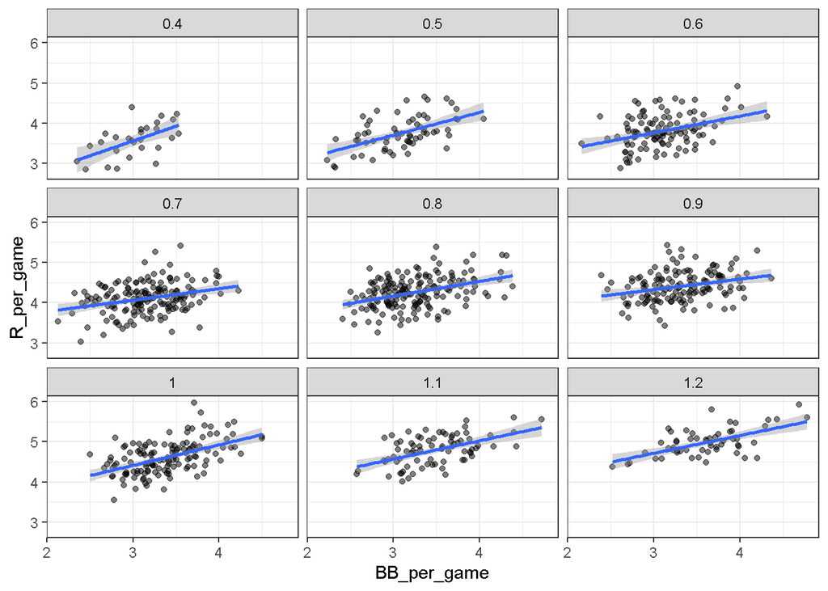

```r
# stratfy HR per game to nearest 10, filter out strata with few points
dat <- Teams %>% filter(yearID %in% 1961:2001) %>%
  mutate(HR_strata = round(HR/G, 1),
         BB_per_game = BB / G,
         R_per_game = R / G) %>%
  filter(HR_strata >= 0.4 & HR_strata <=1.2)

# scatterplot for each HR stratum
dat %>%
  ggplot(aes(BB_per_game, R_per_game)) +
  geom_point(alpha = 0.5) +
  geom_smooth(method = "lm") +
  facet_wrap( ~ HR_strata)
```

```r
# calculate slope of regression line after stratifying by HR
dat %>%
  group_by(HR_strata) %>%
  summarize(slope = cor(BB_per_game, R_per_game)*sd(R_per_game)/sd(BB_per_game))
```

```
## # A tibble: 9 x 2
##   HR_strata slope
##       <dbl> <dbl>
## 1       0.4 0.734
## 2       0.5 0.566
## 3       0.6 0.412
## 4       0.7 0.285
## 5       0.8 0.365
## 6       0.9 0.261
## 7       1   0.511
## 8       1.1 0.454
## 9       1.2 0.440
```

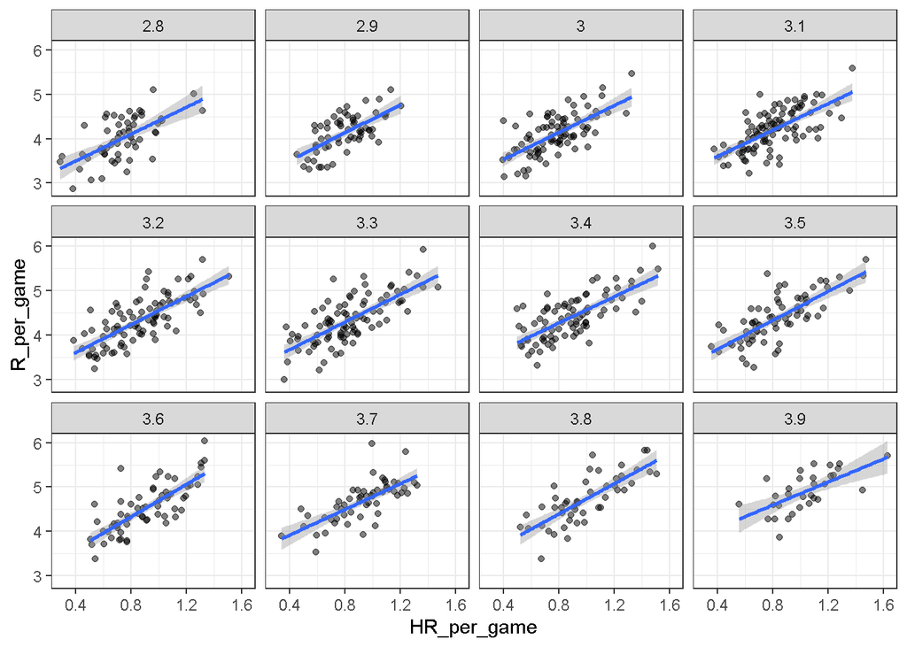

```r
# stratify by BB
dat <- Teams %>% filter(yearID %in% 1961:2001) %>%
  mutate(BB_strata = round(BB/G, 1),
         HR_per_game = HR / G,
         R_per_game = R / G) %>%
  filter(BB_strata >= 2.8 & BB_strata <=3.9)

# scatterplot for each BB stratum
dat %>% ggplot(aes(HR_per_game, R_per_game)) +
  geom_point(alpha = 0.5) +
  geom_smooth(method = "lm") +
  facet_wrap( ~ BB_strata)
```

```r
# slope of regression line after stratifying by BB
dat %>%
  group_by(BB_strata) %>%
  summarize(slope = cor(HR_per_game, R_per_game)*sd(R_per_game)/sd(HR_per_game))
```

```
## # A tibble: 12 x 2
##    BB_strata slope
##        <dbl> <dbl>
##  1       2.8  1.52
##  2       2.9  1.57
##  3       3    1.52
##  4       3.1  1.49
##  5       3.2  1.58
##  6       3.3  1.56
##  7       3.4  1.48
##  8       3.5  1.63
##  9       3.6  1.83
## 10       3.7  1.45
## 11       3.8  1.70
## 12       3.9  1.30
```

### 2.2.3 Linear Models

**Textbook link**  
Here is the link to the [textbook section on linear models.](https://rafalab.github.io/dsbook/linear-models.html#lse)

**Key points**

- “Linear” here does not refer to lines, but rather to the fact that the conditional expectation is a linear combination of known quantities.
- In Galton’s model, we assume $Y$ (son’s height) is a linear combination of a constant and $X$ (father’s height) plus random noise. We further assume that $\epsilon_i$ are independent from each other, have expected value 0 and the standard deviation $\sigma$ which does not depend on $i$.
- Note that if we further assume that $\epsilon$ is normally distributed, then the model is exactly the same one we derived earlier by assuming bivariate normal data.
- We can subtract the mean from $X$ to make $\beta_0$ more interpretable.

### 2.2.4 Assessment: Introduction to Linear Models

#### 2.2.4.1 Question 1

Why is the number of home runs considered a confounder of the relationship between bases on balls and runs per game?

- Home runs is not a confounder of this relationship.
- Home runs are the primary cause of runs per game.
- The correlation between home runs and runs per game is stronger than the correlation between bases on balls and runs per game.
- **Players who get more bases on balls also tend to have more home runs; in addition, home runs increase the points per game.**

**Explanation**  
Number of home runs is a confounder of the relationship between bases on balls and runs per game because players who get more bases on balls also tend to have more home runs and home runs also increase the points/runs scored per game.

#### 2.2.4.2 Question 2

As described in the videos, when we stratified our regression lines for runs per game vs. bases on balls by the number of home runs, what happened?

- The slope of runs per game vs. bases on balls within each stratum was reduced because we removed confounding by home runs.
- The slope of runs per game vs. bases on balls within each stratum was reduced because there were fewer data points.
- The slope of runs per game vs. bases on balls within each stratum increased after we removed confounding by home runs.
- The slope of runs per game vs. bases on balls within each stratum stayed about the same as the original slope.

**Explanation**  
Home runs are a confounder in the runs per game vs. bases on balls regression analysis. When we removed confounding by home runs, the slope of runs per game vs. bases on balls within each stratum decreased.

#### 2.2.4.3 Question 3

We run a linear model for sons’ heights vs. fathers’ heights using the Galton height data, and get the following results:

```
 > lm(son ~ father, data = galton_heights)

Call:
lm(formula = son ~ father, data = galton_heights)

Coefficients:
(Intercept)    father
    35.71       0.50
```

Interpret the numeric coefficient for “father.”

- For every inch we increase the son’s height, the predicted father’s height increases by 0.5 inches.
- **For every inch we increase the father’s height, the predicted son’s height grows by 0.5 inches.**
- For every inch we increase the father’s height, the predicted son’s height is 0.5 times greater.

**Explanation**  
The coefficient for “father” gives the predicted increase in son’s height for each increase of 1 unit in the father’s height. In this case, it means that for every inch we increase the father’s height, the son’s predicted height increases by 0.5 inches.

#### 2.2.4.4 Question 4

We want the intercept term for our model to be more interpretable, so we run the same model as before but now we subtract the mean of fathers’ heights from each individual father’s height to create a new variable centered at zero.

```
galton_heights <- galton_heights %>%
    mutate(father_centered=father - mean(father))
```

We run a linear model using this centered fathers’ height variable.

```
> lm(son ~ father_centered, data = galton_heights)

Call:
lm(formula = son ~ father_centered, data = galton_heights)

Coefficients:
(Intercept)    father_centered
    70.45          0.50
```

Interpret the numeric coefficient for the intercept.

- **The height of a son of a father of average height is 70.45 inches.**
- The height of a son when a father’s height is zero is 70.45 inches.
- The height of an average father is 70.45 inches.

**Explanation**  
Because the fathers’ heights (the independent variable) have been centered on their mean, the intercept represents the height of the son of a father of average height. In this case, that means that the height of a son of a father of average height is 70.45 inches.

If we had not centered fathers’ heights to its mean, then the intercept would represent the height of a son when a father’s height is zero.

#### 2.2.4.5 Question 5

Suppose we fit a multivariate regression model for expected runs based on BB and HR:

$$E\left [R|BB=x_1,HR=x_2\right ]=\beta_0+\beta_1x_1+\beta_2x_2$$

Suppose we fix $BB=x_1$. Then we observe a linear relationship between runs and HR with intercept of:

- $\beta_0$
- $\beta_0+\beta_2x_2$
- $\mathbf{\beta_0+\beta_1x_1}$ **<==**
- $\beta_0+\beta_2x_1$

**Explanation**  
If $x_1$ is fixed, then $\beta_1x_1$ is fixed and acts as the intercept for this regression model. This is the basis of stratificaton.

#### 2.2.4.6 Question 6

Which of the following are assumptions for the errors $\epsilon_i$ in a linear regression model?

- **The** $\mathbf{\epsilon_i}$ **are independent of each other**
- **The** $\mathbf{\epsilon_i}$ **have expected value 0**
- **The variance of** $\mathbf{\epsilon_i}$ **is a constant**

## 2.3 2.2: Least Squares Estimates

### 2.3.1 Least Squares Estimates (LSE)

**Textbook link**  
The textbook section on [least squares estimates can be found here.](https://rafalab.github.io/dsbook/linear-models.html#lse)

**Key points**

- For regression, we aim to find the coefficient values that minimize the distance of the fitted model to the data.
- Residual sum of squares (RSS) measures the distance between the true value and the predicted value given by the regression line. The values that minimize the RSS are called the least squares estimates (LSE).
- We can use partial derivatives to get the values for $\beta_0$ and $\beta_1$ in Galton’s data.

**Code**

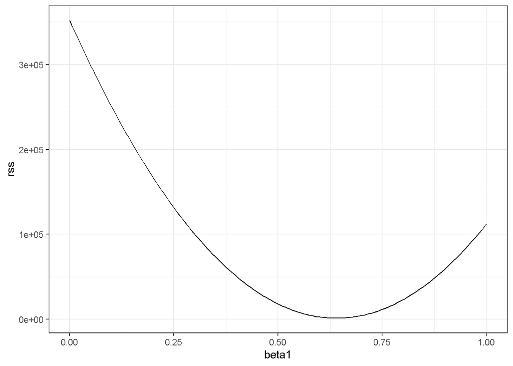

```r
# compute RSS for any pair of beta0 and beta1 in Galton's data
library(HistData)
data("GaltonFamilies")
set.seed(1983)
galton_heights <- GaltonFamilies %>%
  filter(gender == "male") %>%
  group_by(family) %>%
  sample_n(1) %>%
  ungroup() %>%
  select(father, childHeight) %>%
  rename(son = childHeight)
rss <- function(beta0, beta1, data){
    resid <- galton_heights$son - (beta0+beta1*galton_heights$father)
    return(sum(resid^2))
}

# plot RSS as a function of beta1 when beta0=25
beta1 = seq(0, 1, len=nrow(galton_heights))
results <- data.frame(beta1 = beta1,
                      rss = sapply(beta1, rss, beta0 = 25))
results %>% ggplot(aes(beta1, rss)) + geom_line() +
  geom_line(aes(beta1, rss))
```

### 2.3.2 The lm Function

**Textbook link**  
The textbook section on the **lm** [function can be found here.](https://rafalab.github.io/dsbook/linear-models.html#the-lm-function)

**Key points**

- When calling the **`lm`** function, the variable that we want to predict is put to the left of the ~ symbol, and the variables that we use to predict is put to the right of the ~ symbol. The intercept is added automatically.
- LSEs are random variables.

**Code**

```r
# fit regression line to predict son's height from father's height
fit <- lm(son ~ father, data = galton_heights)
fit
```

```
##
## Call:
## lm(formula = son ~ father, data = galton_heights)
##
## Coefficients:
## (Intercept)       father
##     38.7646       0.4411
```

```r
# summary statistics
summary(fit)
```

```
##
## Call:
## lm(formula = son ~ father, data = galton_heights)
##
## Residuals:
##     Min      1Q  Median      3Q     Max
## -9.4228 -1.7022  0.0333  1.5670  9.3567
##
## Coefficients:
##             Estimate Std. Error t value Pr(>|t|)
## (Intercept) 38.76457    5.41093   7.164 2.03e-11 ***
## father       0.44112    0.07825   5.637 6.72e-08 ***
## ---
## Signif. codes:  0 '***' 0.001 '**' 0.01 '*' 0.05 '.' 0.1 ' ' 1
##
## Residual standard error: 2.659 on 177 degrees of freedom
## Multiple R-squared:  0.1522, Adjusted R-squared:  0.1474
## F-statistic: 31.78 on 1 and 177 DF,  p-value: 6.719e-08
```

### 2.3.3 LSE are Random Variables

**Textbook link**  
The textbook section on [LSE can be found here.](https://rafalab.github.io/dsbook/linear-models.html#lse-are-random-variables)

**Key points**

- Because they are derived from the samples, LSE are random variables.
- $\beta_0$ and $\beta_1$ appear to be normally distributed because the central limit theorem plays a role.
- The t-statistic depends on the assumption that $\epsilon$ follows a normal distribution.

**Code**

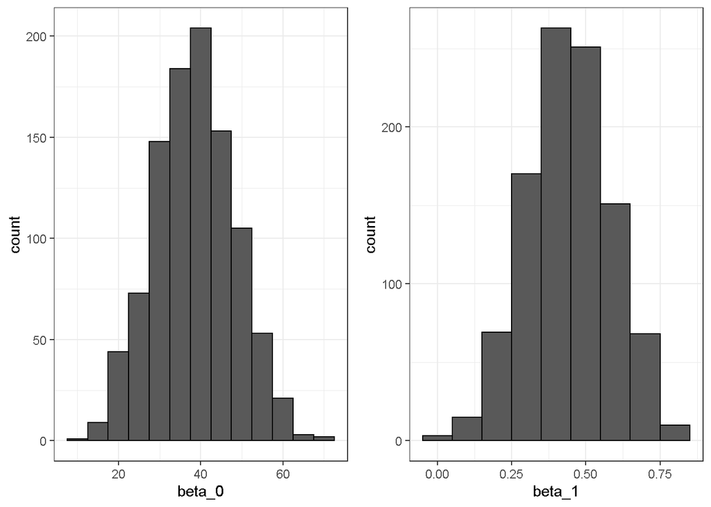

```r
# Monte Carlo simulation
B <- 1000
N <- 50
lse <- replicate(B, {
  sample_n(galton_heights, N, replace = TRUE) %>%
    lm(son ~ father, data = .) %>%
    .$coef
})
lse <- data.frame(beta_0 = lse[1,], beta_1 = lse[2,])

# Plot the distribution of beta_0 and beta_1
library(gridExtra)
p1 <- lse %>% ggplot(aes(beta_0)) + geom_histogram(binwidth = 5, color = "black")
p2 <- lse %>% ggplot(aes(beta_1)) + geom_histogram(binwidth = 0.1, color = "black")
grid.arrange(p1, p2, ncol = 2)
```

```r
# summary statistics
sample_n(galton_heights, N, replace = TRUE) %>%
  lm(son ~ father, data = .) %>%
  summary %>%
  .$coef
```

```
##               Estimate Std. Error  t value     Pr(>|t|)
## (Intercept) 34.4729422  8.6021831 4.007464 0.0002129225
## father       0.4990193  0.1240572 4.022493 0.0002030210
```

```r
lse %>% summarize(se_0 = sd(beta_0), se_1 = sd(beta_1))
```

```
##       se_0      se_1
## 1 9.683973 0.1411404
```

### 2.3.4 Advanced Note on LSE

Although interpretation is not straight-forward, it is also useful to know that the LSE can be strongly correlated, which can be seen using this code:

```r
lse %>% summarize(cor(beta_0, beta_1))
```

```
##   cor(beta_0, beta_1)
## 1          -0.9993386
```

However, the correlation depends on how the predictors are defined or transformed.

Here we standardize the father heights, which changes $x_i$ to $x_i−\bar{x}$.

```r
B <- 1000
N <- 50
lse <- replicate(B, {
      sample_n(galton_heights, N, replace = TRUE) %>%
      mutate(father = father - mean(father)) %>%
      lm(son ~ father, data = .) %>% .$coef
})
```

Observe what happens to the correlation in this case:

```r
cor(lse[1,], lse[2,])
```

```
## [1] 0.1100929
```

### 2.3.5 Predicted Variables are Random Variables

**Textbook link**  
The textbook section on [predicted values can be found here.](https://rafalab.github.io/dsbook/linear-models.html#predicted-values-are-random-variables)

**Key points**

- The predicted value is often denoted as $\hat{Y}$, which is a random variable. Mathematical theory tells us what the standard error of the predicted value is.
- The `predict` function in R can give us predictions directly.

**Code**

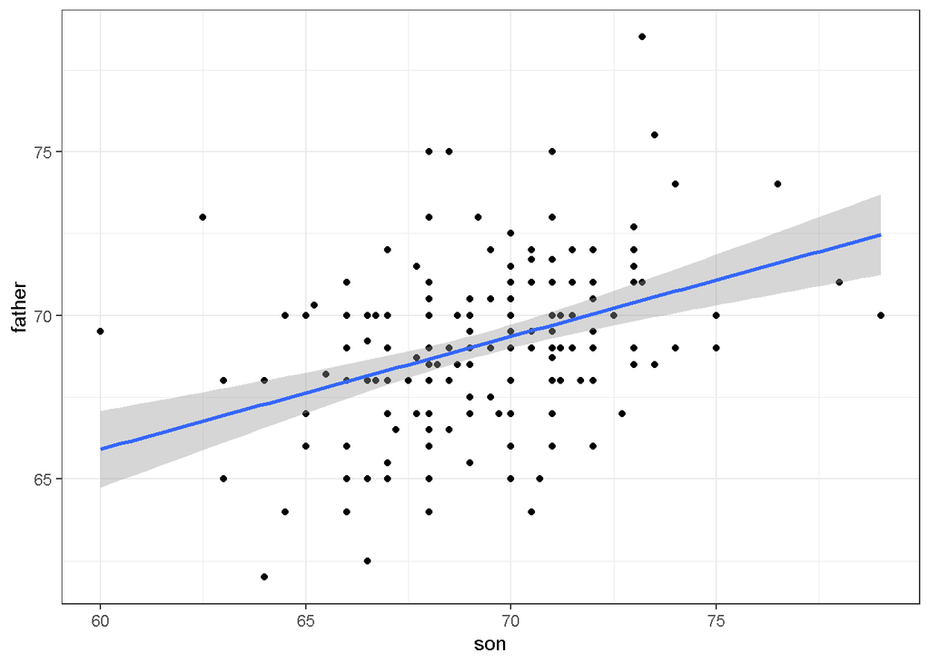

```r
# plot predictions and confidence intervals
galton_heights %>% ggplot(aes(son, father)) +
  geom_point() +
  geom_smooth(method = "lm")
```

```r
# predict Y directly
fit <- galton_heights %>% lm(son ~ father, data = .)
Y_hat <- predict(fit, se.fit = TRUE)
names(Y_hat)
```

```
## [1] "fit"            "se.fit"         "df"             "residual.scale"
```

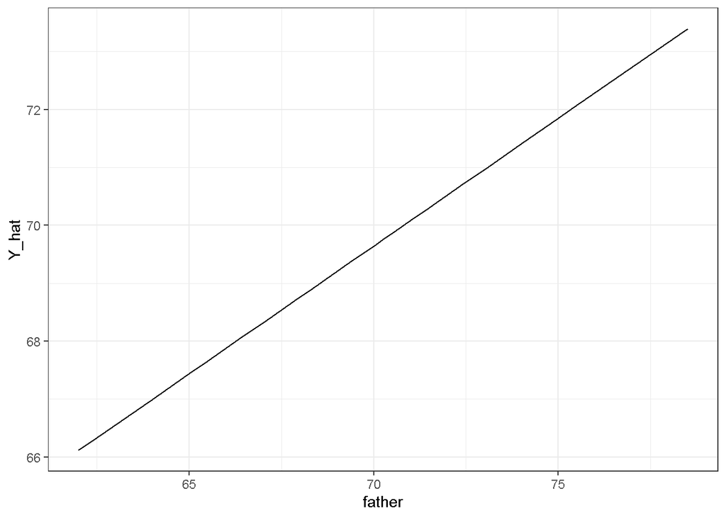

```r
# plot best fit line
galton_heights %>%
  mutate(Y_hat = predict(lm(son ~ father, data=.))) %>%
  ggplot(aes(father, Y_hat))+
  geom_line()
```

### 2.3.6 Assessment: Least Squares Estimates, part 1

#### 2.3.6.1 Question 1

The following code was used in the video to plot RSS with $\beta_0=25$.

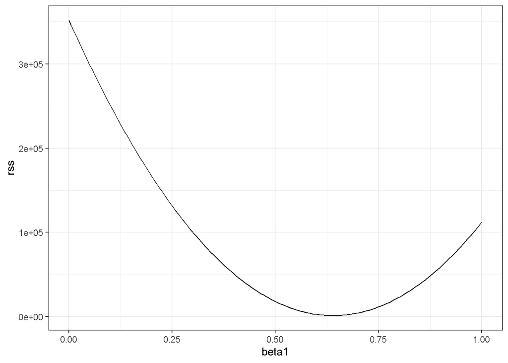

```r
beta1 = seq(0, 1, len=nrow(galton_heights))
results <- data.frame(beta1 = beta1,
                      rss = sapply(beta1, rss, beta0 = 25))
results %>% ggplot(aes(beta1, rss)) + geom_line() +
  geom_line(aes(beta1, rss), col=2)
```

In a model for sons’ heights vs fathers’ heights, what is the least squares estimate (LSE) for $\beta_1$ if we assume $\hat{\beta}_0$ is 36? Hint: modify the code above to do your analysis.

- 0.65
- **0.5**
- 0.2
- 12

**Answer**  
You can tell from a plot of RSS vs $\beta_1$ that the minimum estimate is 0.5

**Explanation**  
Using the code from the video, you can plot RSS vs β1 to find the value for β1 that minimizes the RSS. In this case, that value is 0.5 when we assume that β^0 is 36.

When we assumed that $\hat{\beta}_0$ was 25, as in the sample code, the LSE for $\beta_1$ was 0.65.

#### 2.3.6.2 Question 2

The least squares estimates for the parameters $\beta_0,\beta_1,…,\beta_n$ minimize the residual sum of squares.

**Explanation**  
The least squares estimates minimize, not maximize, the residual sum of squares.

#### 2.3.6.3 Question 3

Load the `Lahman` library and filter the `Teams` data frame to the years 1961-2001. Run a linear model in R predicting the number of runs per game based on *both* the number of bases on balls per game *and* the number of home runs per game.

What is the coefficient for bases on balls?

- **0.39**
- 1.56
- 1.74
- 0.027

**Explanation**  
The coefficient for bases on balls is 0.39; the coefficient for home runs is 1.56; the intercept is 1.74; the standard error for the BB coefficient is 0.027.

#### 2.3.6.4 Question 4

We run a Monte Carlo simulation where we repeatedly take samples of N = 100 from the Galton heights data and compute the regression slope coefficients for each sample:

```r
B <- 1000
N <- 100
lse <- replicate(B, {
    sample_n(galton_heights, N, replace = TRUE) %>%
    lm(son ~ father, data = .) %>% .$coef
})

lse <- data.frame(beta_0 = lse[1,], beta_1 = lse[2,])
```

What does the central limit theorem tell us about the variables beta_0 and beta_1? Select ALL that apply.

- **They are approximately normally distributed.**
- **The expected value of each is the true value of** $\mathbf{\beta_0}$ **and** $\mathbf{\beta_1}$ **(assuming the Galton heights data is a complete population).**
- The central limit theorem does not apply in this situation.
- It allows us to test the hypothesis that $\beta_0=0$ and $\beta_1=0$.

**Answer**  
With a large enough N, the distributions of both beta_0 and beta_1 are approximately normal.

**Explanation**  
With a large enough N, the central limit theorem applies and tells us that the distributions of both beta_0 and beta_1 are approximately normal. The expected values of beta_0 and beta_1 are the true values of $\beta_0$ and $\beta_1$, assuming that the Galton heights data are a complete population.

For hypothesis testing, we assume that the errors in the model are normally distributed.

#### 2.3.6.5 Question 5

In an earlier video, we ran the following linear model and looked at a summary of the results.

```
> mod <- lm(son ~ father, data = galton_heights)
> summary(mod)

Call:
lm(formula = son ~ father, data = galton_heights)

Residuals:
   Min     1Q  Median     3Q    Max
-5.902  -1.405  0.092    1.342  8.092

Coefficients:
                 Estimate  Std. Error  t value     Pr(>|t|)
(Intercept)     35.7125     4.5174       7.91    2.8e-13 ***
father           0.5028     0.0653       7.70    9.5e-13 ***
---
Signif. codes:  0 ‘***’ 0.001 ‘**’ 0.01 ‘*’ 0.05 ‘.’ 0.1 ‘ ’ 1
```

What null hypothesis is the second p-value (the one in the father row) testing?

- $\beta_1=1$, where $\beta_1$ is the coefficient for the variable “father.”
- $\beta_1=0.503$, where $\beta_1$ is the coefficient for the variable “father.”
- $\mathbf{\beta_1=0}$, **where** $\mathbf{\beta_1}$ **is the coefficient for the variable "father.**"

**Explanation**  
The p-value for “father” tests the null hypothesis that $\beta_1=0$, i.e., the fathers’ heights are not associated with the sons’ heights, where $\beta_1$ is the coefficient for the variable father.

#### 2.3.6.6 Question 6

Which R code(s) below would properly plot the predictions and confidence intervals for our linear model of sons’ heights? Select ALL that apply.

```
galton_heights %>% ggplot(aes(father, son)) +
    geom_point() +
    geom_smooth()
```

- **`galton_heights %>% ggplot(aes(father, son)) +`**  
  **`geom_point() +`**  
  **`geom_smooth(method = "lm")`**
- **`model <- lm(son ~ father, data = galton_heights)`**  
  **`predictions <- predict(model, interval = c("confidence"), level = 0.95)`**  
  **`data <- as.tibble(predictions) %>% bind_cols(father = galton_heights$father)`**

**`ggplot(data, aes(x = father, y = fit)) +`**  
**`geom_line(color = "blue", size = 1) +`**  
**`geom_ribbon(aes(ymin=lwr, ymax=upr), alpha=0.2) +`**  
**`geom_point(data = galton_heights, aes(x = father, y = son))`**

```
model <- lm(son ~ father, data = galton_heights)
predictions <- predict(model)
data <- as.tibble(predictions) %>% bind_cols(father = galton_heights$father)

ggplot(data, aes(x = father, y = fit)) +
    geom_line(color = "blue", size = 1) +
    geom_point(data = galton_heights, aes(x = father, y = son))
```

**Answer**  
This is one way to plot predictions and confidence intervals for a linear model of sons’ heights vs. fathers’ heights. This is one of two correct answers. Correct. This code uses the predict command to generate predictions and 95% confidence intervals for the linear model of sons’ heights vs. fathers’ heights. This is one of two correct answers.

### 2.3.7 Assessment: Least Squares Estimates, part 2

In Questions 7 and 8, you’ll look again at female heights from **GaltonFamilies**.

Define **female_heights**, a set of mother and daughter heights sampled from **GaltonFamilies**, as follows:

```r
set.seed(1989, sample.kind="Rounding") #if you are using R 3.6 or later
```

```r
library(HistData)
data("GaltonFamilies")
options(digits = 3)    # report 3 significant digits
female_heights <- GaltonFamilies %>%
    filter(gender == "female") %>%
    group_by(family) %>%
    sample_n(1) %>%
    ungroup() %>%
    select(mother, childHeight) %>%
    rename(daughter = childHeight)
```

#### 2.3.7.1 Question 7

Fit a linear regression model predicting the mothers’ heights using daughters’ heights.

What is the slope of the model?

```r
fit <- lm(mother ~ daughter, data = female_heights)
fit$coef[2]
```

```
## daughter
##     0.31
```

What the intercept of the model?

```r
fit$coef[1]
```

```
## (Intercept)
##        44.2
```

#### 2.3.7.2 Question 8

Predict mothers’ heights using the model.

What is the predicted height of the first mother in the dataset?

```r
predict(fit)[1]
```

```
##    1
## 65.6
```

What is the actual height of the first mother in the dataset?

```r
female_heights$mother[1]
```

```
## [1] 67
```

We have shown how BB and singles have similar predictive power for scoring runs. Another way to compare the usefulness of these baseball metrics is by assessing how stable they are across the years. Because we have to pick players based on their previous performances, we will prefer metrics that are more stable. In these exercises, we will compare the stability of singles and BBs.

Before we get started, we want to generate two tables: one for 2002 and another for the average of 1999-2001 seasons. We want to define per plate appearance statistics, keeping only players with more than 100 plate appearances. Here is how we create the 2002 table:

```r
library(Lahman)
bat_02 <- Batting %>% filter(yearID == 2002) %>%
    mutate(pa = AB + BB, singles = (H - X2B - X3B - HR)/pa, bb = BB/pa) %>%
    filter(pa >= 100) %>%
    select(playerID, singles, bb)
```

#### 2.3.7.3 Question 9

Now compute a similar table but with rates computed over 1999-2001. Keep only rows from 1999-2001 where players have 100 or more plate appearances, then calculate the average single rate (`mean_singles`) and average BB rate (`mean_bb`) per player over those three seasons.

How many players had a single rate `mean_singles` of greater than 0.2 per plate appearance over 1999-2001?

```r
bat_99_01 <- Batting %>% filter(yearID %in% 1999:2001) %>%
    mutate(pa = AB + BB, singles = (H - X2B - X3B - HR)/pa, bb = BB/pa) %>%
    filter(pa >= 100) %>%
    group_by(playerID) %>%
    summarize(mean_singles = mean(singles), mean_bb = mean(bb))
sum(bat_99_01$mean_singles > 0.2)
```

```
## [1] 46
```

How many players had a BB rate mean_bb of greater than 0.2 per plate appearance over 1999-2001?

```r
sum(bat_99_01$mean_bb > 0.2)
```

```
## [1] 3
```

#### 2.3.7.4 Question 10

Use `inner_join` to combine the `bat_02` table with the table of 1999-2001 rate averages you created in the previous question.

What is the correlation between 2002 singles rates and 1999-2001 average singles rates?

```r
dat <- inner_join(bat_02, bat_99_01)
cor(dat$singles, dat$mean_singles)
```

```
## [1] 0.551
```

What is the correlation between 2002 BB rates and 1999-2001 average BB rates?

```r
cor(dat$bb, dat$mean_bb)
```

```
## [1] 0.717
```

#### 2.3.7.5 Question 11

Make scatterplots of `mean_singles` versus `singles` and `mean_bb` versus `bb`.

Are either of these distributions bivariate normal?

- Neither distribution is bivariate normal.
- `singles` and `mean_singles` are bivariate normal, but `bb` and `mean_bb` are not.
- `bb` and `mean_bb` are bivariate normal, but `singles` and `mean_singles` are not.
- Both distributions are bivariate normal.

**Explanation**  
Both distributions are bivariate normal, as can be seen in the scatter plots made using the following code:

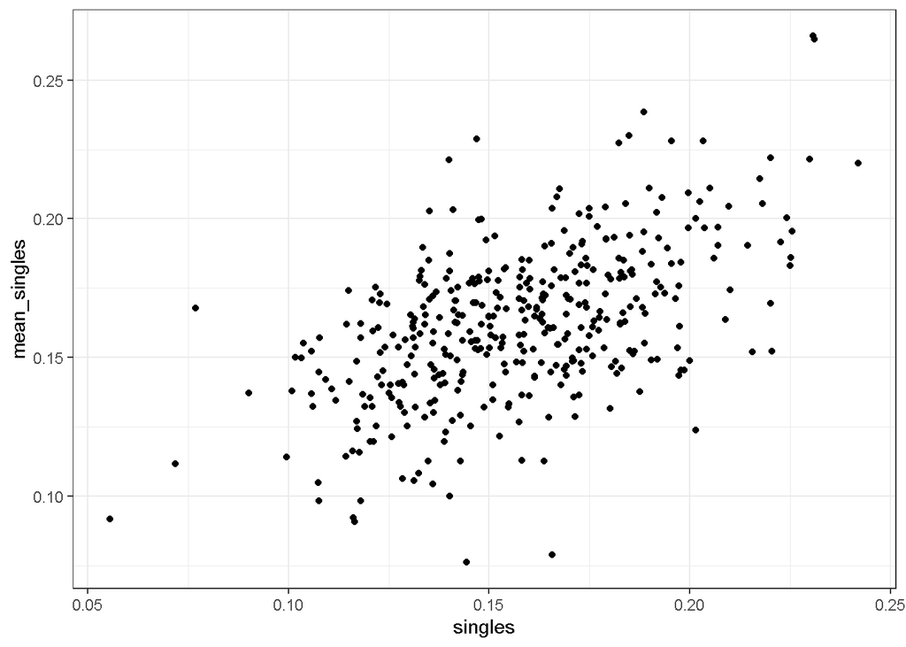

```r
dat %>%
    ggplot(aes(singles, mean_singles)) +
    geom_point()
```

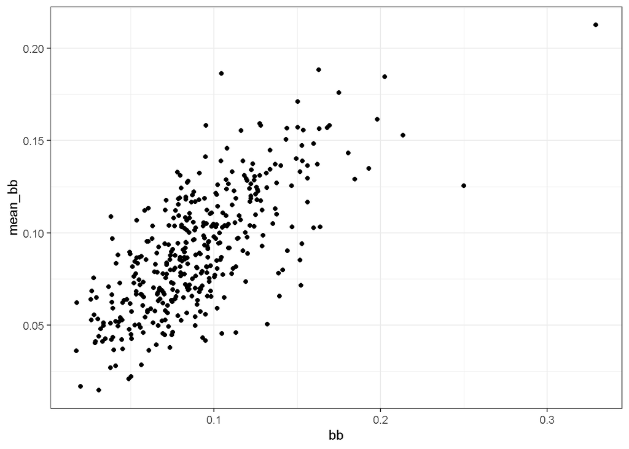

```r
dat %>%
    ggplot(aes(bb, mean_bb)) +
    geom_point()
```

#### 2.3.7.6 Question 12

Fit a linear model to predict 2002 singles given 1999-2001 mean_singles.

What is the coefficient of mean_singles, the slope of the fit?

```r
fit_singles <- lm(singles ~ mean_singles, data = dat)
fit_singles$coef[2]
```

```
## mean_singles
##        0.588
```

Fit a linear model to predict 2002 bb given 1999-2001 mean_bb.

What is the coefficient of `mean_bb`, the slope of the fit?

```r
fit_bb <- lm(bb ~ mean_bb, data = dat)
fit_bb$coef[2]
```

```
## mean_bb
##   0.829
```

## 2.4 2.3: Tibbles, do, and broom

### 2.4.1 Advanced dplyr: Tibbles

**Textbook link**  
The textbook section [discussing tibbles can be found here.](https://rafalab.github.io/dsbook/linear-models.html#linear-regression-in-the-tidyverse)

**Key points**

- Tibbles can be regarded as a modern version of data frames and are the default data structure in the tidyverse.
- Some functions that do not work properly with data frames do work with tibbles.

**Code**

```r
# stratify by HR
dat <- Teams %>% filter(yearID %in% 1961:2001) %>%
  mutate(HR = round(HR/G, 1),
         BB = BB/G,
         R = R/G) %>%
  select(HR, BB, R) %>%
  filter(HR >= 0.4 & HR<=1.2)

# calculate slope of regression lines to predict runs by BB in different HR strata
dat %>%
  group_by(HR) %>%
  summarize(slope = cor(BB,R)*sd(R)/sd(BB))
```

```
## # A tibble: 9 x 2
##      HR slope
##   <dbl> <dbl>
## 1   0.4 0.734
## 2   0.5 0.566
## 3   0.6 0.412
## 4   0.7 0.285
## 5   0.8 0.365
## 6   0.9 0.261
## 7   1   0.511
## 8   1.1 0.454
## 9   1.2 0.440
```

```r
# use lm to get estimated slopes - lm does not work with grouped tibbles
dat %>%
  group_by(HR) %>%
  lm(R ~ BB, data = .) %>%
  .$coef
```

```
## (Intercept)          BB
##       2.198       0.638
```

```r
# inspect a grouped tibble
dat %>% group_by(HR) %>% head()
```

```
## # A tibble: 6 x 3
## # Groups:   HR [5]
##      HR    BB     R
##   <dbl> <dbl> <dbl>
## 1   0.9  3.56  4.24
## 2   0.7  3.97  4.47
## 3   0.8  3.37  4.69
## 4   1.1  3.46  4.42
## 5   1    2.75  4.61
## 6   0.9  3.06  4.58
```

```r
dat %>% group_by(HR) %>% class()
```

```
## [1] "grouped_df" "tbl_df"     "tbl"        "data.frame"
```

### 2.4.2 Tibbles: Differences from Data Frames

**Key points**

- Tibbles are more readable than data frames.
- If you subset a data frame, you may not get a data frame. If you subset a tibble, you always get a tibble.
- Tibbles can hold more complex objects such as lists or functions.
- Tibbles can be grouped.

**Code**

```r
# inspect data frame and tibble
Teams
```

```
##      yearID lgID teamID franchID divID Rank   G Ghome   W   L DivWin WCWin
## 1      1871   NA    BS1      BNA  <NA>    3  31    NA  20  10   <NA>  <NA>
## 2      1871   NA    CH1      CNA  <NA>    2  28    NA  19   9   <NA>  <NA>
## 3      1871   NA    CL1      CFC  <NA>    8  29    NA  10  19   <NA>  <NA>
## 4      1871   NA    FW1      KEK  <NA>    7  19    NA   7  12   <NA>  <NA>
## 5      1871   NA    NY2      NNA  <NA>    5  33    NA  16  17   <NA>  <NA>
## 6      1871   NA    PH1      PNA  <NA>    1  28    NA  21   7   <NA>  <NA>
## 7      1871   NA    RC1      ROK  <NA>    9  25    NA   4  21   <NA>  <NA>
## 8      1871   NA    TRO      TRO  <NA>    6  29    NA  13  15   <NA>  <NA>
## 9      1871   NA    WS3      OLY  <NA>    4  32    NA  15  15   <NA>  <NA>
## 10     1872   NA    BL1      BLC  <NA>    2  58    NA  35  19   <NA>  <NA>
## 11     1872   NA    BR1      ECK  <NA>    9  29    NA   3  26   <NA>  <NA>
## 12     1872   NA    BR2      BRA  <NA>    6  37    NA   9  28   <NA>  <NA>
## 13     1872   NA    BS1      BNA  <NA>    1  48    NA  39   8   <NA>  <NA>
## 14     1872   NA    CL1      CFC  <NA>    7  22    NA   6  16   <NA>  <NA>
```

[output cut: 12490 more lines]

```r
as.tibble(Teams)
```

```
## # A tibble: 2,895 x 48
##    yearID lgID  teamID franchID divID  Rank     G Ghome     W     L DivWin WCWin
##     <int> <fct> <fct>  <fct>    <chr> <int> <int> <int> <int> <int> <chr>  <chr>
##  1   1871 NA    BS1    BNA      <NA>      3    31    NA    20    10 <NA>   <NA>
##  2   1871 NA    CH1    CNA      <NA>      2    28    NA    19     9 <NA>   <NA>
##  3   1871 NA    CL1    CFC      <NA>      8    29    NA    10    19 <NA>   <NA>
##  4   1871 NA    FW1    KEK      <NA>      7    19    NA     7    12 <NA>   <NA>
##  5   1871 NA    NY2    NNA      <NA>      5    33    NA    16    17 <NA>   <NA>
##  6   1871 NA    PH1    PNA      <NA>      1    28    NA    21     7 <NA>   <NA>
##  7   1871 NA    RC1    ROK      <NA>      9    25    NA     4    21 <NA>   <NA>
##  8   1871 NA    TRO    TRO      <NA>      6    29    NA    13    15 <NA>   <NA>
##  9   1871 NA    WS3    OLY      <NA>      4    32    NA    15    15 <NA>   <NA>
## 10   1872 NA    BL1    BLC      <NA>      2    58    NA    35    19 <NA>   <NA>
## # … with 2,885 more rows, and 36 more variables: LgWin <chr>, WSWin <chr>,
## #   R <int>, AB <int>, H <int>, X2B <int>, X3B <int>, HR <int>, BB <dbl>,
## #   SO <int>, SB <dbl>, CS <dbl>, HBP <dbl>, SF <int>, RA <int>, ER <int>,
## #   ERA <dbl>, CG <int>, SHO <int>, SV <int>, IPouts <int>, HA <int>,
## #   HRA <int>, BBA <int>, SOA <int>, E <int>, DP <int>, FP <dbl>, name <chr>,
## #   park <chr>, attendance <int>, BPF <int>, PPF <int>, teamIDBR <chr>,
## #   teamIDlahman45 <chr>, teamIDretro <chr>
```

```r
# subsetting a data frame sometimes generates vectors
class(Teams[,20])
```

```
## [1] "integer"
```

```r
# subsetting a tibble always generates tibbles
class(as.tibble(Teams[,20]))
```

```
## [1] "tbl_df"     "tbl"        "data.frame"
```

```r
# pulling a vector out of a tibble
class(as.tibble(Teams)$HR)
```

```
## [1] "integer"
```

```r
# access a non-existing column in a data frame or a tibble
Teams$hr
```

```r
as.tibble(Teams)$hr
```

```r
# create a tibble with complex objects
tibble(id = c(1, 2, 3), func = c(mean, median, sd))
```

```
## # A tibble: 3 x 2
##      id func
##   <dbl> <list>
## 1     1 <fn>
## 2     2 <fn>
## 3     3 <fn>
```

### 2.4.3 do

**Textbook link** The textbook section [discussing the **do** function can be found here.](https://rafalab.github.io/dsbook/linear-models.html#linear-regression-in-the-tidyverse)

**Key points**

- The **`do()`** function serves as a bridge between R functions, such as **`lm()`**, and the **tidyverse**.
- We have to specify a column when using the `do()` function, otherwise we will get an error.
- If the data frame being returned has more than one row, the rows will be concatenated appropriately.

**Code**

```r
# use do to fit a regression line to each HR stratum
dat %>%
    group_by(HR) %>%
    do(fit = lm(R ~ BB, data = .))
```

```
## Source: local data frame [9 x 2]
## Groups: <by row>
##
## # A tibble: 9 x 2
##      HR fit
## * <dbl> <list>
## 1   0.4 <lm>
## 2   0.5 <lm>
## 3   0.6 <lm>
## 4   0.7 <lm>
## 5   0.8 <lm>
## 6   0.9 <lm>
## 7   1   <lm>
## 8   1.1 <lm>
## 9   1.2 <lm>
```

```
# using do without a column name gives an error
dat %>%
    group_by(HR) %>%
    do(lm(R ~ BB, data = .))
Error: Results 1, 2, 3, 4, 5, ... must be data frames, not lm
```

```r
# define a function to extract slope from lm
get_slope <- function(data){
  fit <- lm(R ~ BB, data = data)
  data.frame(slope = fit$coefficients[2],
             se = summary(fit)$coefficient[2,2])
}

# return the desired data frame
dat %>%
  group_by(HR) %>%
  do(get_slope(.))
```

```
## # A tibble: 9 x 3
## # Groups:   HR [9]
##      HR slope     se
##   <dbl> <dbl>  <dbl>
## 1   0.4 0.734 0.208
## 2   0.5 0.566 0.110
## 3   0.6 0.412 0.0974
## 4   0.7 0.285 0.0705
## 5   0.8 0.365 0.0653
## 6   0.9 0.261 0.0754
## 7   1   0.511 0.0749
## 8   1.1 0.454 0.0855
## 9   1.2 0.440 0.0801
```

```r
# not the desired output: a column containing data frames
dat %>%
  group_by(HR) %>%
  do(slope = get_slope(.))
```

```
## Source: local data frame [9 x 2]
## Groups: <by row>
##
## # A tibble: 9 x 2
##      HR slope
## * <dbl> <list>
## 1   0.4 <df[,2] [1 × 2]>
## 2   0.5 <df[,2] [1 × 2]>
## 3   0.6 <df[,2] [1 × 2]>
## 4   0.7 <df[,2] [1 × 2]>
## 5   0.8 <df[,2] [1 × 2]>
## 6   0.9 <df[,2] [1 × 2]>
## 7   1   <df[,2] [1 × 2]>
## 8   1.1 <df[,2] [1 × 2]>
## 9   1.2 <df[,2] [1 × 2]>
```

```r
# data frames with multiple rows will be concatenated appropriately
get_lse <- function(data){
  fit <- lm(R ~ BB, data = data)
  data.frame(term = names(fit$coefficients),
    slope = fit$coefficients,
    se = summary(fit)$coefficient[,2])
}
dat %>%
  group_by(HR) %>%
  do(get_lse(.))
```

```
## # A tibble: 18 x 4
## # Groups:   HR [9]
##       HR term        slope     se
##    <dbl> <fct>       <dbl>  <dbl>
##  1   0.4 (Intercept) 1.36  0.631
##  2   0.4 BB          0.734 0.208
##  3   0.5 (Intercept) 2.01  0.344
##  4   0.5 BB          0.566 0.110
##  5   0.6 (Intercept) 2.53  0.305
##  6   0.6 BB          0.412 0.0974
##  7   0.7 (Intercept) 3.21  0.225
##  8   0.7 BB          0.285 0.0705
##  9   0.8 (Intercept) 3.07  0.213
## 10   0.8 BB          0.365 0.0653
## 11   0.9 (Intercept) 3.54  0.252
## 12   0.9 BB          0.261 0.0754
## 13   1   (Intercept) 2.88  0.255
## 14   1   BB          0.511 0.0749
## 15   1.1 (Intercept) 3.21  0.300
## 16   1.1 BB          0.454 0.0855
## 17   1.2 (Intercept) 3.40  0.291
## 18   1.2 BB          0.440 0.0801
```

### 2.4.4 broom

**Textbook link**  
The textbook section on the [**broom** package can be found here.](https://rafalab.github.io/dsbook/linear-models.html#the-broom-package)

**Key points**

- The **broom** package has three main functions, all of which extract information from the object returned by `lm` and return it in a **tidyverse** friendly data frame.
- The `tidy` function returns estimates and related information as a data frame.
- The functions `glance` and `augment` relate to model specific and observation specific outcomes respectively.

**Code**

```r
# use tidy to return lm estimates and related information as a data frame
library(broom)
fit <- lm(R ~ BB, data = dat)
tidy(fit)
```

```
## # A tibble: 2 x 5
##   term        estimate std.error statistic  p.value
##   <chr>          <dbl>     <dbl>     <dbl>    <dbl>
## 1 (Intercept)    2.20     0.113       19.4 1.12e-70
## 2 BB             0.638    0.0344      18.5 1.35e-65
```

```r
# add confidence intervals with tidy
tidy(fit, conf.int = TRUE)
```

```
## # A tibble: 2 x 7
##   term        estimate std.error statistic  p.value conf.low conf.high
##   <chr>          <dbl>     <dbl>     <dbl>    <dbl>    <dbl>     <dbl>
## 1 (Intercept)    2.20     0.113       19.4 1.12e-70    1.98      2.42
## 2 BB             0.638    0.0344      18.5 1.35e-65    0.570     0.705
```

```r
# pipeline with lm, do, tidy
dat %>%
  group_by(HR) %>%
  do(tidy(lm(R ~ BB, data = .), conf.int = TRUE)) %>%
  filter(term == "BB") %>%
  select(HR, estimate, conf.low, conf.high)
```

```
## # A tibble: 9 x 4
## # Groups:   HR [9]
##      HR estimate conf.low conf.high
##   <dbl>    <dbl>    <dbl>     <dbl>
## 1   0.4    0.734    0.308     1.16
## 2   0.5    0.566    0.346     0.786
## 3   0.6    0.412    0.219     0.605
## 4   0.7    0.285    0.146     0.425
## 5   0.8    0.365    0.236     0.494
## 6   0.9    0.261    0.112     0.410
## 7   1      0.511    0.363     0.660
## 8   1.1    0.454    0.284     0.624
## 9   1.2    0.440    0.280     0.601
```

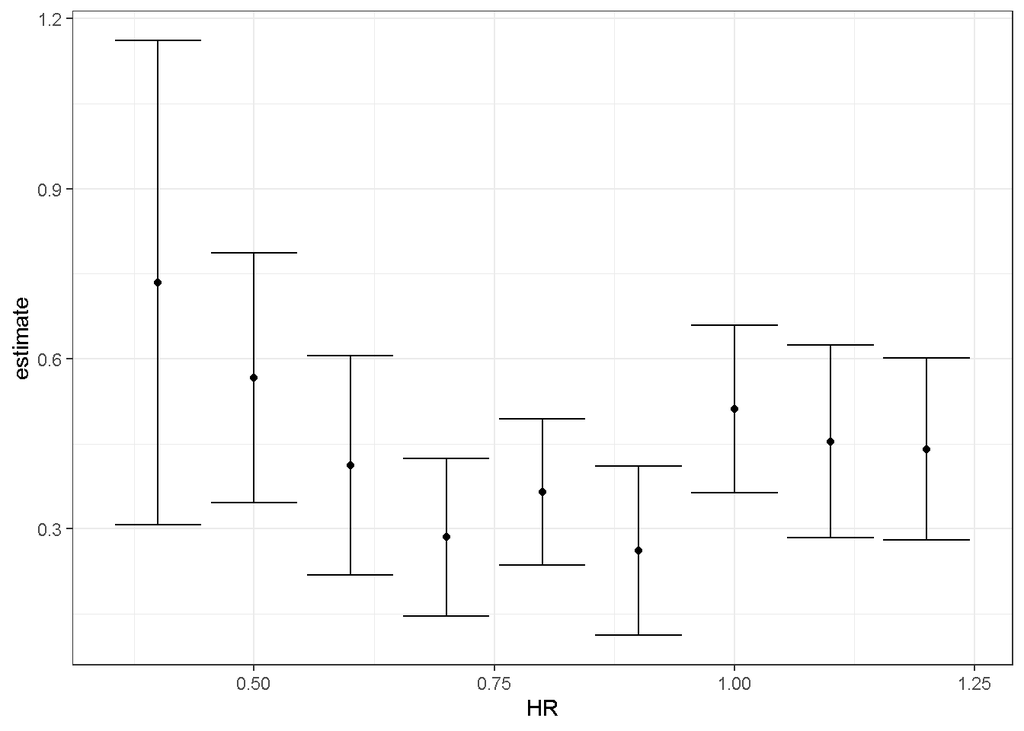

```r
# make ggplots
dat %>%
  group_by(HR) %>%
  do(tidy(lm(R ~ BB, data = .), conf.int = TRUE)) %>%
  filter(term == "BB") %>%
  select(HR, estimate, conf.low, conf.high) %>%
  ggplot(aes(HR, y = estimate, ymin = conf.low, ymax = conf.high)) +
  geom_errorbar() +
  geom_point()
```

```r
# inspect with glance
glance(fit)
```

```
## # A tibble: 1 x 11
##   r.squared adj.r.squared sigma statistic  p.value    df logLik   AIC   BIC
##       <dbl>         <dbl> <dbl>     <dbl>    <dbl> <int>  <dbl> <dbl> <dbl>
## 1     0.266         0.265 0.454      343. 1.35e-65     2  -596. 1199. 1214.
## # … with 2 more variables: deviance <dbl>, df.residual <int>
```

### 2.4.5 Assessment: Tibbles, do, and broom, part 1

#### 2.4.5.1 Question 1

As seen in the videos, what problem do we encounter when we try to run a linear model on our baseball data, grouping by home runs?

- There is not enough data in some levels to run the model.
- **The `lm` function does not know how to handle grouped tibbles.**
- The results of the `lm` function cannot be put into a tidy format.

**Explanation**  
The `lm` function does not know how to handle grouped tibbles, so we can’t simply run a linear model on the baseball data grouped by home runs. We need something to bridge between the grouped tibble and the `lm` function.

#### 2.4.5.2 Question 2

Tibbles are similar to what other class in R?

- Vectors
- Matrices
- **Data frames**
- Lists

**Explanation**  
Tibbles are essentially modern versions of data frames.

#### 2.4.5.3 Question 3

What are some advantages of tibbles compared to data frames? Select ALL that apply.

- **Tibbles display better.**
- **If you subset a tibble, you always get back a tibble.**
- **Tibbles can have complex entries.**
- **Tibbles can be grouped.**

**Explanation**  
All of the listed answers are advantages of tibbles when compared to data frames: tibbles display better, they always return tibbles when subsetted, they can have complex entries, and they can be grouped.

#### 2.4.5.4 Question 4

What are two advantages of the `do` command, when applied to the tidyverse? Select TWO.

- It is faster than normal functions.
- It returns useful error messages.
- **It understands grouped tibbles.**
- **It always returns a data.frame.**

**Answer**  
The `do` function can understand grouped tibbles. The `do` function always returns a data.frame.

**Explanation**  
The `do` function serves as a useful bridge between base R functions and the tidyverse. It understands grouped tibbles and always returns a `data.frame`.

#### 2.4.5.5 Question 5

You want to take the tibble `dat`, which we used in the video on the `do` function, and run the linear model R ~ BB for each strata of HR. Then you want to add three new columns to your grouped tibble: the coefficient, standard error, and p-value for the BB term in the model.

You’ve already written the function get_slope, shown below.

```r
get_slope <- function(data) {
  fit <- lm(R ~ BB, data = data)
  sum.fit <- summary(fit)

  data.frame(slope = sum.fit$coefficients[2, "Estimate"],
             se = sum.fit$coefficients[2, "Std. Error"],
             pvalue = sum.fit$coefficients[2, "Pr(>|t|)"])
}
```

What additional code could you write to accomplish your goal?

```
dat %>%
  group_by(HR) %>%
  do(get_slope)
```

- **`dat %>%`**  
  **`group_by(HR) %>%`**  
  **`do(get_slope(.))`**

```
dat %>%
  group_by(HR) %>%
  do(slope = get_slope(.))
```

```
dat %>%
  do(get_slope(.))
```

**Answer**  
This will create a tibble with four columns: `HR`, `slope`, `se`, and `pvalue` for each level of `HR`.

**Explanation**

```r
dat %>%
  group_by(HR) %>%
  do(get_slope(.))
```

```
## # A tibble: 9 x 4
## # Groups:   HR [9]
##      HR slope     se   pvalue
##   <dbl> <dbl>  <dbl>    <dbl>
## 1   0.4 0.734 0.208  1.54e- 3
## 2   0.5 0.566 0.110  3.02e- 6
## 3   0.6 0.412 0.0974 4.80e- 5
## 4   0.7 0.285 0.0705 7.93e- 5
## 5   0.8 0.365 0.0653 9.13e- 8
## 6   0.9 0.261 0.0754 7.12e- 4
## 7   1   0.511 0.0749 3.00e-10
## 8   1.1 0.454 0.0855 1.03e- 6
## 9   1.2 0.440 0.0801 1.07e- 6
```

This is the only command that correctly creates a tibble with four columns: `HR`, `slope`, `se`, and `pvalue` for each level of HR. The data frame must be passed to `get_slope` using `.`. If you name the results of the `do` command such as in the code `do(slope = get_slope(.))`, that will save all results in a single column called `slope`. If you forget `group_by`, then the results will be a model on the data as a whole, rather than on the data stratified by home runs.

#### 2.4.5.6 Question 6

The output of a `broom` function is always what?

- **A data.frame**
- A list
- A vector

**Explanation**  
The `broom` function always outputs a `data.frame`.

#### 2.4.5.7 Question 7

You want to know whether the relationship between home runs and runs per game varies by baseball league. You create the following dataset:

```r
dat <- Teams %>% filter(yearID %in% 1961:2001) %>%
  mutate(HR = HR/G,
         R = R/G) %>%
  select(lgID, HR, BB, R)
```

What code would help you quickly answer this question?

- **`dat %>%`**  
  **`group_by(lgID) %>%`**  
  **`do(tidy(lm(R ~ HR, data = .), conf.int = T)) %>%`**  
  **`filter(term == "HR")`**

```
dat %>%
  group_by(lgID) %>%
  do(glance(lm(R ~ HR, data = .)))
```

```
dat %>%
  do(tidy(lm(R ~ HR, data = .), conf.int = T)) %>%
  filter(term == "HR")
```

```
dat %>%
  group_by(lgID) %>%
  do(mod = lm(R ~ HR, data = .))
```

**Answer**  
This is a good application of the command `tidy`, from the `broom` package.

**Explanation**

```r
dat %>%
  group_by(lgID) %>%
  do(tidy(lm(R ~ HR, data = .), conf.int = T)) %>%
  filter(term == "HR")
```

```
## # A tibble: 2 x 8
## # Groups:   lgID [2]
##   lgID  term  estimate std.error statistic  p.value conf.low conf.high
##   <fct> <chr>    <dbl>     <dbl>     <dbl>    <dbl>    <dbl>     <dbl>
## 1 AL    HR        1.90    0.0734      25.9 1.29e-95     1.75      2.04
## 2 NL    HR        1.76    0.0671      26.2 1.16e-95     1.62      1.89
```

This code is a good application of the command `tidy`, from the `broom` package.

The `glance` function provides data on model fit rather than on effect estimates and confidence intervals. If you forget the line `group_by(lgID)`, your code will give you a single estimate for the entire dataset because you have not grouped the data by league ID.

```r
dat %>%
  group_by(lgID) %>%
  do(mod = lm(R ~ HR, data = .))
```

```
## Source: local data frame [2 x 2]
## Groups: <by row>
##
## # A tibble: 2 x 2
##   lgID  mod
## * <fct> <list>
## 1 AL    <lm>
## 2 NL    <lm>
```

This code gives get a data.frame with the column `mod`, which contains the linear model results. While it is possible to then extract effect estimates and confidence intervals from this model, it is not nearly as easy as using the `tidy` function.

### 2.4.6 Assessment: Tibbles, do, and broom, part 2

We have investigated the relationship between fathers’ heights and sons’ heights. But what about other parent-child relationships? Does one parent’s height have a stronger association with child height? How does the child’s gender affect this relationship in heights? Are any differences that we observe statistically significant?

The `galton` dataset is a sample of one male and one female child from each family in the **GaltonFamilies** dataset. The `pair` column denotes whether the pair is father and daughter, father and son, mother and daughter, or mother and son.

Create the galton dataset using the code below:

```r
library(tidyverse)
library(HistData)
data("GaltonFamilies")
set.seed(1) # if you are using R 3.5 or earlier
set.seed(1, sample.kind = "Rounding") # if you are using R 3.6 or later
galton <- GaltonFamilies %>%
    group_by(family, gender) %>%
    sample_n(1) %>%
    ungroup() %>%
    gather(parent, parentHeight, father:mother) %>%
    mutate(child = ifelse(gender == "female", "daughter", "son")) %>%
    unite(pair, c("parent", "child"))

galton
```

```
## # A tibble: 710 x 8
##    family midparentHeight children childNum gender childHeight pair
##    <fct>            <dbl>    <int>    <int> <fct>        <dbl> <chr>
##  1 001               75.4        4        2 female        69.2 fath…
##  2 001               75.4        4        1 male          73.2 fath…
##  3 002               73.7        4        4 female        65.5 fath…
##  4 002               73.7        4        2 male          72.5 fath…
##  5 003               72.1        2        2 female        68   fath…
##  6 003               72.1        2        1 male          71   fath…
##  7 004               72.1        5        5 female        63   fath…
##  8 004               72.1        5        2 male          68.5 fath…
##  9 005               69.1        6        5 female        62.5 fath…
## 10 005               69.1        6        1 male          72   fath…
## # … with 700 more rows, and 1 more variable: parentHeight <dbl>
```

#### 2.4.6.1 Question 8

Group by `pair` and summarize the number of observations in each group.

How many father-daughter pairs are in the dataset?

How many mother-son pairs are in the dataset?

**Explanation**  
The following code will give the number of observations in each of the four groups:

```r
galton %>%
    group_by(pair) %>%
    summarize(n = n())
```

```
## # A tibble: 4 x 2
##   pair                n
##   <chr>           <int>
## 1 father_daughter   176
## 2 father_son        179
## 3 mother_daughter   176
## 4 mother_son        179
```

#### 2.4.6.2 Question 9

Calculate the correlation coefficients for fathers and daughters, fathers and sons, mothers and daughters and mothers and sons.

Which pair has the **strongest** correlation in heights?

- fathers and daughters
- **fathers and sons**
- mothers and daughters
- mothers and sons

**Explanation**  
The following code will give the maximum correlation:

```r
galton %>%
    group_by(pair) %>%
    summarize(cor = cor(parentHeight, childHeight)) %>%
    filter(cor == max(cor))
```

```
## # A tibble: 1 x 2
##   pair         cor
##   <chr>      <dbl>
## 1 father_son 0.430
```

Which pair has the **weakest** correlation in heights?

- fathers and daughters
- fathers and sons
- mothers and daughters
- **mothers and sons**

**Explanation**  
The following code will give the minimum correlation:

```r
galton %>%
    group_by(pair) %>%
    summarize(cor = cor(parentHeight, childHeight)) %>%
    filter(cor == min(cor))
```

```
## # A tibble: 1 x 2
##   pair         cor
##   <chr>      <dbl>
## 1 mother_son 0.343
```

#### 2.4.6.3 Question 10

Question 10 has two parts. The information here applies to both parts.

Use `lm` and the `broom` package to fit regression lines for each parent-child pair type. Compute the least squares estimates, standard errors, confidence intervals and p-values for the `parentHeight` coefficient for each pair.

#### 2.4.6.4 Question 10a

What is the estimate of the father-daughter coefficient?

```r
library(broom)
galton %>%
    group_by(pair) %>%
    do(tidy(lm(childHeight ~ parentHeight, data = .), conf.int = TRUE)) %>%
    filter(term == "parentHeight", pair == "father_daughter") %>%
    pull(estimate)
```

```
## [1] 0.345
```

For every 1-inch increase in mother’s height, how many inches does the typical son’s height increase? Give your answer as a number with no units.

```r
galton %>%
    group_by(pair) %>%
    do(tidy(lm(childHeight ~ parentHeight, data = .), conf.int = TRUE)) %>%
    filter(term == "parentHeight", pair == "mother_son") %>%
    pull(estimate)
```

```
## [1] 0.381
```

#### 2.4.6.5 Question 10b

Which sets of parent-child heights are significantly correlated at a p-value cut off of .05? Select ALL that apply.

- **father-daughter**
- **father-son**
- **mother-daughter**
- **mother-son**

**Explanation**  
All of the parent-child heights are correlated with a p-value of <0.05.

Which of the following statements are true? Select ALL that apply.

- **All of the confidence intervals overlap each other.**
- At least one confidence interval covers zero.
- **The confidence intervals involving mothers’ heights are larger than the confidence intervals involving fathers’ heights.**
- The confidence intervals involving daughters’ heights are larger than the confidence intervals involving sons’ heights.
- **The data are consistent with inheritance of height being independent of the child’s gender.**
- **The data are consistent with inheritance of height being independent of the parent’s gender.**

**Explanation**  
The following code can be used to answer both questions:

```r
galton %>%
    group_by(pair) %>%
    do(tidy(lm(childHeight ~ parentHeight, data = .), conf.int = TRUE)) %>%
    filter(term == "parentHeight" & p.value < .05)
```

```
## # A tibble: 4 x 8
## # Groups:   pair [4]
##   pair       term      estimate std.error statistic   p.value conf.low conf.high
##   <chr>      <chr>        <dbl>     <dbl>     <dbl>     <dbl>    <dbl>     <dbl>
## 1 father_da… parentHe…    0.345    0.0599      5.77   3.56e-8    0.227     0.464
## 2 father_son parentHe…    0.443    0.0700      6.33   1.94e-9    0.305     0.581
## 3 mother_da… parentHe…    0.394    0.0720      5.47   1.56e-7    0.252     0.536
## 4 mother_son parentHe…    0.381    0.0784      4.86   2.59e-6    0.226     0.535
```

All four of the confidence intervals overlap. The confidence intervals for mothers’ heights are larger than those for fathers’ heights, as observed from the standard errors. Because the confidence intervals overlap, the data are consistent with inheritance of height being independent of the child’s or the parent’s gender.

## 2.5 2.4: Regression and Baseball

### 2.5.1 Building a Better Offensive Metric for Baseball

**Textbook link**  
The textbook section on the [continuation of the Moneyball case study can be found here.](https://rafalab.github.io/dsbook/linear-models.html#case-study-moneyball-continued)

**Code**

```r
# linear regression with two variables
fit <- Teams %>%
  filter(yearID %in% 1961:2001) %>%
  mutate(BB = BB/G, HR = HR/G,  R = R/G) %>%
  lm(R ~ BB + HR, data = .)
tidy(fit, conf.int = TRUE)
```

```
## # A tibble: 3 x 7
##   term        estimate std.error statistic   p.value conf.low conf.high
##   <chr>          <dbl>     <dbl>     <dbl>     <dbl>    <dbl>     <dbl>
## 1 (Intercept)    1.74     0.0824      21.2 7.62e- 83    1.58      1.91
## 2 BB             0.387    0.0270      14.3 1.20e- 42    0.334     0.440
## 3 HR             1.56     0.0490      31.9 1.78e-155    1.47      1.66
```

```r
# regression with BB, singles, doubles, triples, HR
fit <- Teams %>%
  filter(yearID %in% 1961:2001) %>%
  mutate(BB = BB / G,
         singles = (H - X2B - X3B - HR) / G,
         doubles = X2B / G,
         triples = X3B / G,
         HR = HR / G,
         R = R / G) %>%
  lm(R ~ BB + singles + doubles + triples + HR, data = .)
coefs <- tidy(fit, conf.int = TRUE)
coefs
```

```
## # A tibble: 6 x 7
##   term        estimate std.error statistic   p.value conf.low conf.high
##   <chr>          <dbl>     <dbl>     <dbl>     <dbl>    <dbl>     <dbl>
## 1 (Intercept)   -2.77     0.0862     -32.1 4.76e-157   -2.94     -2.60
## 2 BB             0.371    0.0117      31.6 1.87e-153    0.348     0.394
## 3 singles        0.519    0.0127      40.8 8.67e-217    0.494     0.544
## 4 doubles        0.771    0.0226      34.1 8.44e-171    0.727     0.816
## 5 triples        1.24     0.0768      16.1 2.12e- 52    1.09      1.39
## 6 HR             1.44     0.0243      59.3 0.           1.40      1.49
```

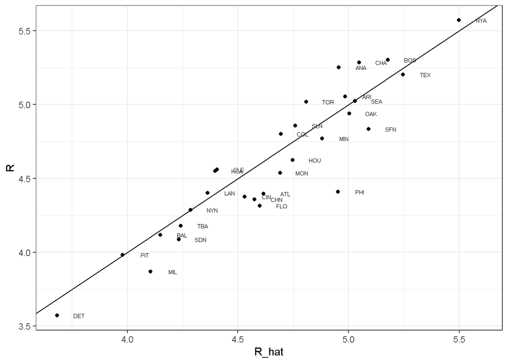

```r
# predict number of runs for each team in 2002 and plot
Teams %>%
  filter(yearID %in% 2002) %>%
  mutate(BB = BB/G,
         singles = (H-X2B-X3B-HR)/G,
         doubles = X2B/G,
         triples =X3B/G,
         HR=HR/G,
         R=R/G)  %>%
  mutate(R_hat = predict(fit, newdata = .)) %>%
  ggplot(aes(R_hat, R, label = teamID)) +
  geom_point() +
  geom_text(nudge_x=0.1, cex = 2) +
  geom_abline()
```

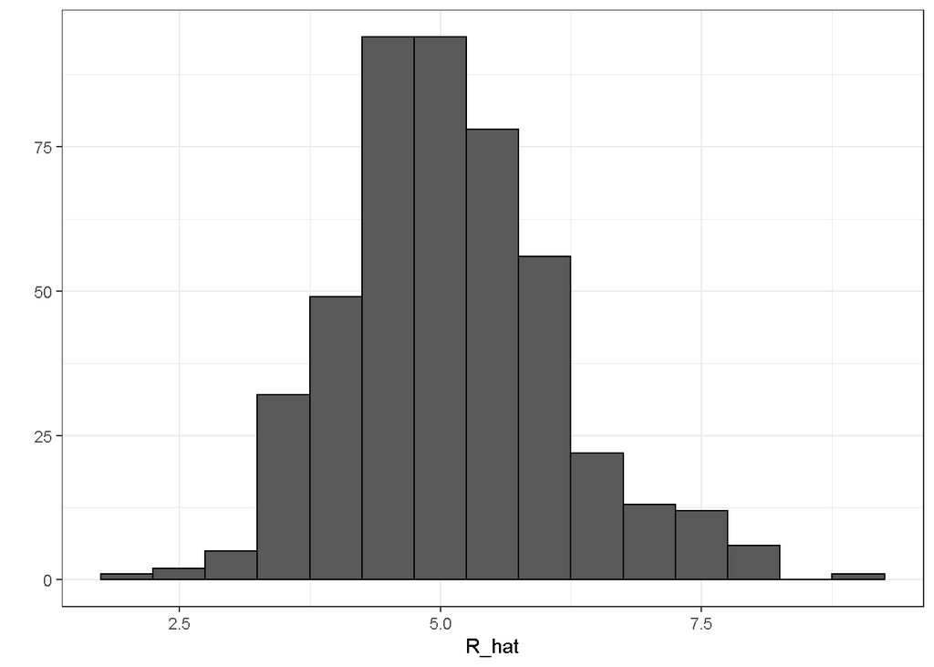

```r
# average number of team plate appearances per game
pa_per_game <- Batting %>% filter(yearID == 2002) %>%
  group_by(teamID) %>%
  summarize(pa_per_game = sum(AB+BB)/max(G)) %>%
  pull(pa_per_game) %>%
  mean

# compute per-plate-appearance rates for players available in 2002 using previous data
players <- Batting %>% filter(yearID %in% 1999:2001) %>%
  group_by(playerID) %>%
  mutate(PA = BB + AB) %>%
  summarize(G = sum(PA)/pa_per_game,
    BB = sum(BB)/G,
    singles = sum(H-X2B-X3B-HR)/G,
    doubles = sum(X2B)/G,
    triples = sum(X3B)/G,
    HR = sum(HR)/G,
    AVG = sum(H)/sum(AB),
    PA = sum(PA)) %>%
  filter(PA >= 300) %>%
  select(-G) %>%
  mutate(R_hat = predict(fit, newdata = .))

# plot player-specific predicted runs
qplot(R_hat, data = players, geom = "histogram", binwidth = 0.5, color = I("black"))
```